# Sains Data untuk Inovasi dan Pembangunan Regional

## 10.9 Paket Output Klasifikasi Lengkap

```r
class10 <- pr |>
  dplyr::mutate(.pred_class = factor(ifelse(.pred_prioritas >= .5, "prioritas", "non"), levels=levels(prioritas_intervensi)))
cm10 <- yardstick::conf_mat(class10, truth=prioritas_intervensi, estimate=.pred_class)
cm10
```

```
#>            Truth
#> Prediction  prioritas non
#>   prioritas        47   0
#>   non               1 112
```

```r
yardstick::metric_set(yardstick::accuracy, yardstick::sens, yardstick::spec, yardstick::ppv, yardstick::npv, yardstick::f_meas)(
  class10, truth=prioritas_intervensi, estimate=.pred_class, event_level="first"
) |> knitr::kable(digits=3, caption="Metric klasifikasi pada threshold 0,50")
```

Table 10.3: Metric klasifikasi pada threshold 0,50

| .metric | .estimator | .estimate |
| --- | --- | --- |
| accuracy | binary | 0.994 |
| sens | binary | 0.979 |
| spec | binary | 1.000 |
| ppv | binary | 1.000 |
| npv | binary | 0.991 |
| f_meas | binary | 0.989 |

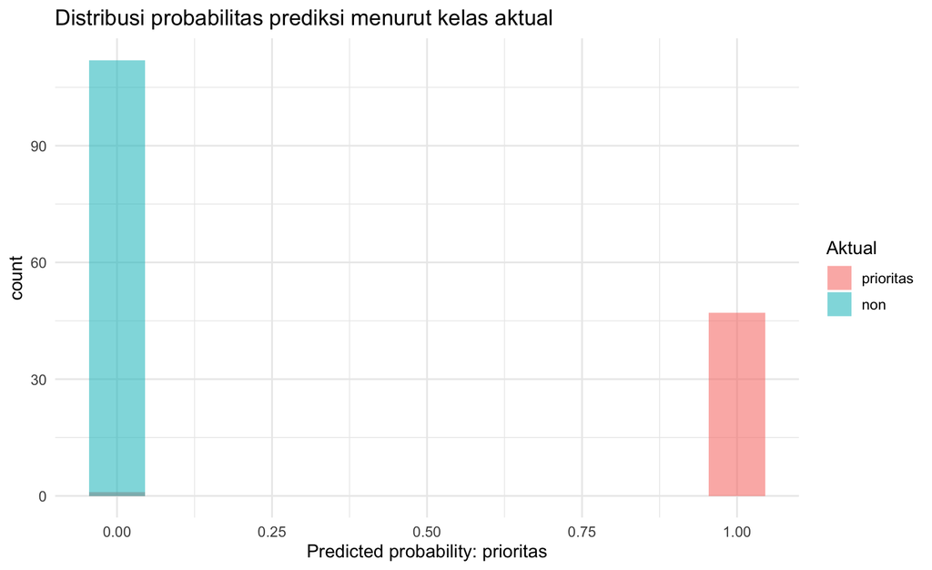

```r
ggplot2::ggplot(pr, ggplot2::aes(.pred_prioritas, fill=prioritas_intervensi)) +
  ggplot2::geom_histogram(position="identity", alpha=.55, bins=12) +
  ggplot2::labs(title="Distribusi probabilitas prediksi menurut kelas aktual", x="Predicted probability: prioritas", fill="Aktual")
```

```r
cal10 <- pr |>
  dplyr::mutate(bin=dplyr::ntile(.pred_prioritas, 5), y=as.integer(prioritas_intervensi=="prioritas")) |>
  dplyr::group_by(bin) |>
  dplyr::summarise(mean_pred=mean(.pred_prioritas), observed_rate=mean(y), n=dplyr::n(), .groups="drop")
knitr::kable(cal10, digits=3, caption="Calibration table per kuintil probabilitas")
```

Table 10.4: Calibration table per kuintil probabilitas

| bin | mean_pred | observed_rate | n |
| --- | --- | --- | --- |
| 1 | 0.000 | 0.0 | 32 |
| 2 | 0.000 | 0.0 | 32 |
| 3 | 0.000 | 0.0 | 32 |
| 4 | 0.469 | 0.5 | 32 |
| 5 | 1.000 | 1.0 | 32 |

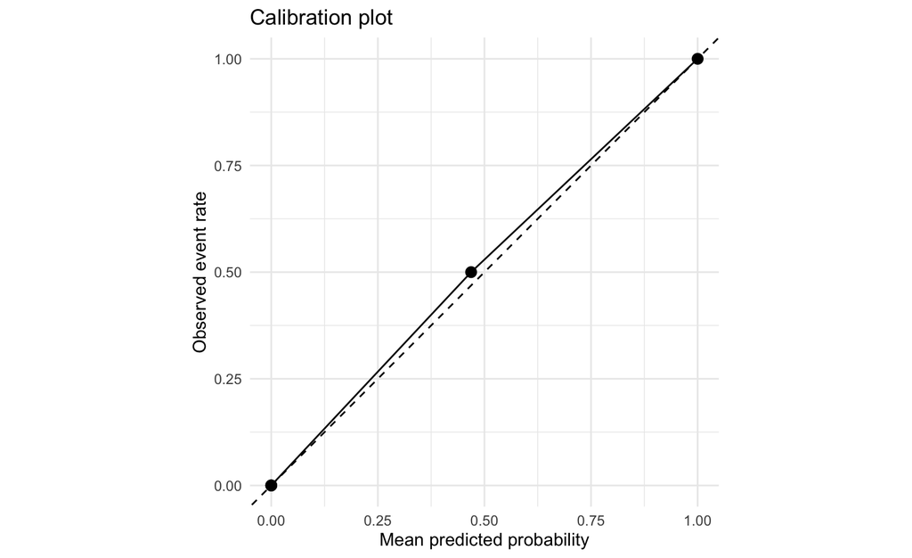

```r
ggplot2::ggplot(cal10, ggplot2::aes(mean_pred, observed_rate)) +
  ggplot2::geom_abline(slope=1,intercept=0,linetype=2) + ggplot2::geom_point(size=3) + ggplot2::geom_line() +
  ggplot2::coord_equal(xlim=c(0,1),ylim=c(0,1)) +
  ggplot2::labs(title="Calibration plot", x="Mean predicted probability", y="Observed event rate")
```

## 10.10 Interpretasi dalam Konteks Regional

Jika recall meningkat dari 0,60 menjadi 0,82 setelah threshold diturunkan, lebih banyak wilayah rentan berhasil terdeteksi, tetapi false positives juga naik. Implikasinya adalah kebutuhan verifikasi lapangan lebih besar. Pilihan threshold harus dibahas bersama kapasitas program.

## 10.11 Latihan

1. Mengapa accuracy dapat menyesatkan pada kelas imbalanced?
2. Bedakan precision dan recall dalam bahasa kebijakan.
3. Apa konsekuensi etis false negative untuk program perlindungan sosial?
4. **Analisis:** bandingkan threshold 0,3; 0,5; 0,7.
5. **Analisis:** buat kurva ROC dan precision-recall.
6. **Mini-case:** pemerintah hanya mampu memverifikasi 100 dari 1.000 desa. Rancang strategi threshold/ranking dan mekanisme human review.

### 10.11.1 Tugas 4 — Classification for Prioritization (2,5%)

Definisikan binary priority outcome dari kasus regional secara transparan. Fit logistic regression dan satu model non-linear. Bandingkan ROC-AUC, PR behavior, sensitivity, precision, calibration, dan minimal tiga threshold. Pilih threshold dengan alasan kapasitas/biaya kebijakan.

### 10.11.2 Kuis 3 — Minggu 9–10 (2,5%)

Kisi-kisi: tree impurity; random forest; boosting; logistic probability/odds; confusion matrix; sensitivity/specificity; precision/F1; ROC-AUC; calibration; threshold berbasis cost.

## 10.12 Hubungan dengan Capstone Project

Jika proyek menggunakan classification, tim harus menyertakan *cost-of-error statement*: siapa yang dirugikan oleh FP/FN dan bagaimana threshold dipilih.

## 10.13 Kesimpulan

Classification adalah mekanisme keputusan. Metric dan threshold harus dikaitkan dengan kapasitas program, risiko, fairness, dan prosedur verifikasi manusia.

## 10.14 Pendalaman Magister — Classification dan decision threshold

### 10.14.1 Audit metodologis

1. Accuracy dipakai pada kelas jarang.
2. Threshold 0.5 dianggap universal.
3. Auc dianggap calibration.
4. Label prioritas dibuat setelah melihat outcome test.
5. Probability tidak dikalibrasi.
6. Cost kebijakan tidak dibahas.

### 10.14.2 Pertanyaan viva / diskusi kelas

1. Apa beda discrimination dan calibration?
2. Kapan PR curve lebih informatif?
3. Bagaimana cost mengubah threshold?
4. Apa beda odds ratio dan probability difference?
5. Mengapa sensitivity tinggi dapat menurunkan precision?
6. Bagaimana kapasitas program masuk keputusan threshold?

# 11 Clustering dan Segmentasi Wilayah

## 11.1 Pendahuluan

*Clustering* digunakan untuk menyusun **tipologi wilayah** berdasarkan kemiripan profil indikator, bukan untuk menentukan peringkat “baik–buruk”. Dalam inovasi regional, segmentasi dapat membantu pemerintah merancang paket intervensi yang berbeda untuk kelompok daerah dengan kebutuhan berbeda. Karena hasil cluster sensitif terhadap pemilihan indikator, skala, *distance metric*, jumlah cluster, dan *initialization*, analisis harus menampilkan proses pemilihan cluster dan profil akhirnya secara transparan. (Kaufman dan Rousseeuw 1990; Hastie, Tibshirani, dan Friedman 2009; James dkk. 2021)

## 11.2 Tujuan Pembelajaran

Setelah pertemuan ini mahasiswa mampu:

1. menjelaskan fungsi objektif K-means dan hierarchical clustering;
2. melakukan standardisasi indikator regional secara benar;
3. membandingkan beberapa nilai $K$ menggunakan WSS dan silhouette;
4. menampilkan keanggotaan dan profil setiap cluster secara rinci;
5. memvisualisasikan cluster melalui PCA dan heatmap profil;
6. melakukan pemeriksaan sensitivitas terhadap pilihan $K$ dan metode pengelompokan; dan
7. menerjemahkan tipologi menjadi strategi regional yang tidak stigmatis.

## 11.3 Definisi dan Konsep

Untuk wilayah $i=1,\ldots,n$ dengan $p$ indikator, tulis vektor fitur sebagai $\mathbf{x}_i=(x_{i1},\ldots,x_{ip})^\top$. Karena indikator memiliki unit berbeda, fitur umumnya distandardisasi:

$$z_{ij}=\frac{x_{ij}-\bar{x}_j}{s_j},$$

dengan $\bar{x}_j$ rata-rata indikator $j$ dan $s_j$ simpangan bakunya.

K-means membagi observasi ke $K$ cluster $C_1,\ldots,C_K$ dengan meminimumkan *within-cluster sum of squares*:

$$\operatorname{WSS}(K)=\sum_{k=1}^{K}\sum_{i\in C_k}\|\mathbf z_i-\boldsymbol\mu_k\|_2^2,$$

di mana $\boldsymbol\mu_k$ adalah centroid cluster $k$.

Untuk observasi $i$, silhouette didefinisikan sebagai

$$s(i)=\frac{b(i)-a(i)}{\max\{a(i),b(i)\}},$$

dengan $a(i)$ rata-rata jarak ke anggota cluster sendiri dan $b(i)$ rata-rata jarak minimum ke cluster lain. Nilai mendekati 1 menunjukkan pemisahan yang baik, mendekati 0 menunjukkan observasi berada di perbatasan, dan negatif mengindikasikan kemungkinan salah pengelompokan. (Rousseeuw 1987)

Hierarchical clustering dengan Ward meminimumkan kenaikan variasi dalam-cluster ketika dua kelompok digabung. Untuk dua cluster $A$ dan $B$, perubahan *error sum of squares* dapat ditulis secara intuitif sebagai fungsi jarak centroid dan ukuran kedua cluster. Karena itu Ward cocok sebagai pembanding K-means ketika tujuan utamanya adalah cluster kompak.

## 11.4 Intuisi Metode

Cluster merupakan **ringkasan geometri data yang dipilih analis**. Jika fitur hanya ekonomi, hasilnya terutama tipologi ekonomi; jika ditambah pendidikan, kesehatan, digitalisasi, dan UMKM, definisi “kemiripan wilayah” berubah. Karena itu pemilihan fitur adalah keputusan substantif, bukan sekadar teknis.

**Prinsip interpretasi:** beri nama cluster berdasarkan pola indikator, misalnya “kemiskinan tinggi–akses digital rendah”, bukan “wilayah gagal” atau “wilayah tertinggal”.

## 11.5 Data Simulasi dan Pemeriksaan Awal

```r
reg11 <- readr::read_csv("data/simulasi_panel_regional.csv", show_col_types = FALSE) |>
  dplyr::filter(tahun == 2025) |>
  dplyr::select(
    wilayah, pdrb_perkapita_juta, kemiskinan_persen, tpt_persen,
    ipm, internet_persen, umkm_per_1000, indeks_inovasi
  ) |>
  tidyr::drop_na()

vars11 <- c("pdrb_perkapita_juta", "kemiskinan_persen", "tpt_persen",
            "ipm", "internet_persen", "umkm_per_1000", "indeks_inovasi")

ringkas11 <- reg11 |>
  dplyr::summarise(dplyr::across(
    dplyr::all_of(vars11),
    list(mean = mean, sd = sd, min = min, median = median, max = max)
  )) |>
  tidyr::pivot_longer(dplyr::everything(), names_to = c("indikator", ".value"), names_pattern = "(.*)_(mean|sd|min|median|max)$")

knitr::kable(ringkas11, digits = 2, caption = "Statistik deskriptif indikator sebelum clustering")
```

Table 11.1: Statistik deskriptif indikator sebelum clustering

| indikator | mean | sd | min | median | max |
| --- | --- | --- | --- | --- | --- |
| pdrb_perkapita_juta | 49.22 | 10.86 | 24.04 | 50.90 | 66.15 |
| kemiskinan_persen | 9.89 | 1.75 | 6.01 | 9.84 | 13.05 |
| tpt_persen | 8.07 | 1.10 | 6.69 | 7.75 | 10.35 |
| ipm | 70.74 | 1.18 | 67.78 | 70.68 | 73.42 |
| internet_persen | 83.44 | 8.19 | 65.66 | 85.60 | 96.99 |
| umkm_per_1000 | 38.60 | 5.12 | 29.37 | 39.66 | 48.99 |
| indeks_inovasi | 68.25 | 4.12 | 60.29 | 69.00 | 76.82 |

Output ini wajib dibaca sebelum standardisasi. Perbedaan rentang yang besar menjelaskan mengapa Euclidean distance pada skala asli dapat didominasi variabel tertentu.

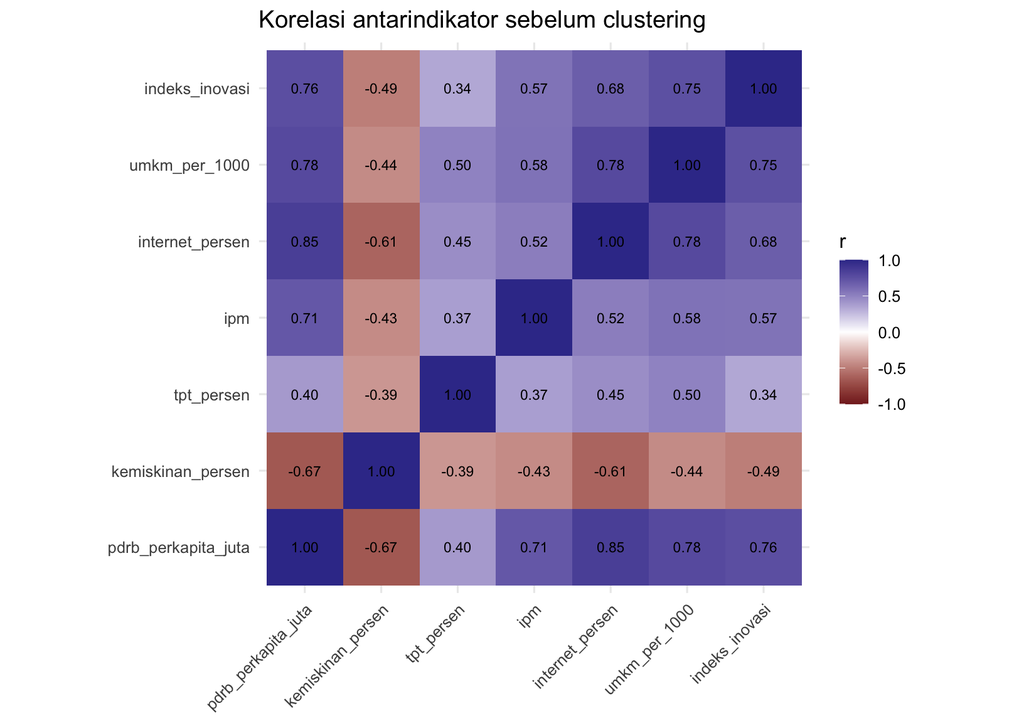

```r
cor11 <- cor(reg11 |> dplyr::select(dplyr::all_of(vars11)), use = "pairwise.complete.obs")
cor_long11 <- as.data.frame(as.table(cor11))

ggplot2::ggplot(cor_long11, ggplot2::aes(Var1, Var2, fill = Freq)) +
  ggplot2::geom_tile() +
  ggplot2::geom_text(ggplot2::aes(label = sprintf("%.2f", Freq)), size = 3) +
  ggplot2::scale_fill_gradient2(limits = c(-1, 1), midpoint = 0) +
  ggplot2::coord_equal() +
  ggplot2::labs(title = "Korelasi antarindikator sebelum clustering", x = NULL, y = NULL, fill = "r") +
  ggplot2::theme(axis.text.x = ggplot2::element_text(angle = 45, hjust = 1))
```

Korelasi tinggi tidak otomatis membuat indikator harus dibuang, tetapi fitur yang sangat redundan dapat memberi bobot geometris berlebih pada satu dimensi substantif.

## 11.6 Standardisasi dan Pemilihan Jumlah Cluster

```r
X11 <- scale(reg11 |> dplyr::select(dplyr::all_of(vars11)))
scale_check11 <- tibble::tibble(
  indikator = colnames(X11),
  mean_z = apply(X11, 2, mean),
  sd_z = apply(X11, 2, sd)
)
knitr::kable(scale_check11, digits = 4, caption = "Pemeriksaan hasil standardisasi")
```

Table 11.2: Pemeriksaan hasil standardisasi

| indikator | mean_z | sd_z |
| --- | --- | --- |
| pdrb_perkapita_juta | 0 | 1 |
| kemiskinan_persen | 0 | 1 |
| tpt_persen | 0 | 1 |
| ipm | 0 | 1 |
| internet_persen | 0 | 1 |
| umkm_per_1000 | 0 | 1 |
| indeks_inovasi | 0 | 1 |

Secara numerik, setiap kolom hasil z-score seharusnya memiliki rata-rata mendekati 0 dan simpangan baku mendekati 1.

```r
set.seed(260811)
d11 <- stats::dist(X11)

eval_k11 <- purrr::map_dfr(2:6, function(k) {
  km_tmp <- stats::kmeans(X11, centers = k, nstart = 100)
  sil_tmp <- cluster::silhouette(km_tmp$cluster, d11)
  tibble::tibble(
    K = k,
    total_WSS = km_tmp$tot.withinss,
    avg_silhouette = mean(sil_tmp[, "sil_width"]),
    betweenSS_ratio = km_tmp$betweenss / km_tmp$totss
  )
})

knitr::kable(eval_k11, digits = 3, caption = "Perbandingan kandidat jumlah cluster")
```

Table 11.3: Perbandingan kandidat jumlah cluster

| K | total_WSS | avg_silhouette | betweenSS_ratio |
| --- | --- | --- | --- |
| 2 | 97.396 | 0.372 | 0.465 |
| 3 | 72.859 | 0.290 | 0.600 |
| 4 | 62.985 | 0.265 | 0.654 |
| 5 | 54.639 | 0.202 | 0.700 |
| 6 | 47.707 | 0.196 | 0.738 |

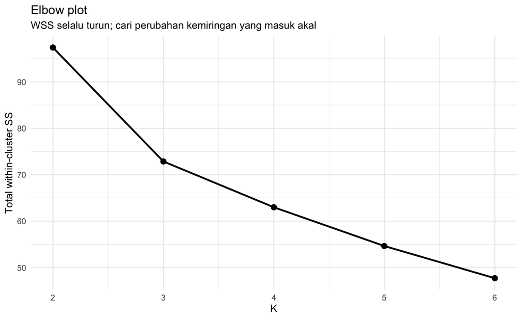

```r
ggplot2::ggplot(eval_k11, ggplot2::aes(K, total_WSS)) +
  ggplot2::geom_line(linewidth = 1) +
  ggplot2::geom_point(size = 2.7) +
  ggplot2::scale_x_continuous(breaks = 2:6) +
  ggplot2::labs(title = "Elbow plot", subtitle = "WSS selalu turun; cari perubahan kemiringan yang masuk akal", y = "Total within-cluster SS")
```

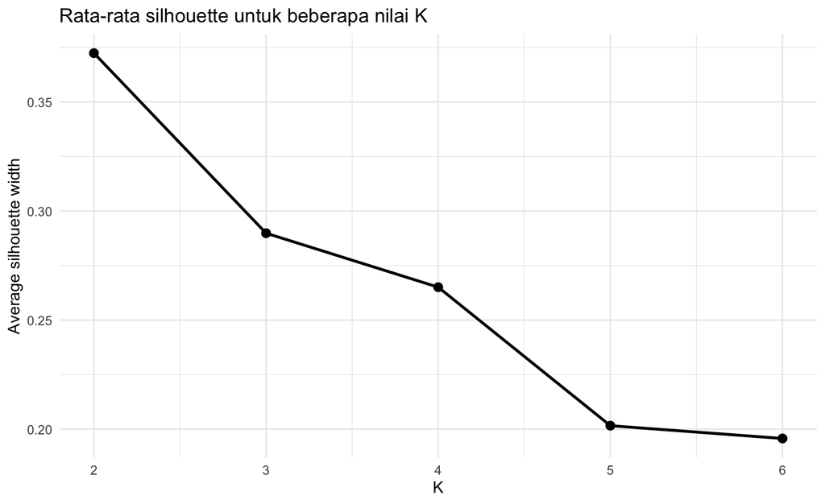

```r
ggplot2::ggplot(eval_k11, ggplot2::aes(K, avg_silhouette)) +
  ggplot2::geom_line(linewidth = 1) +
  ggplot2::geom_point(size = 2.7) +
  ggplot2::scale_x_continuous(breaks = 2:6) +
  ggplot2::labs(title = "Rata-rata silhouette untuk beberapa nilai K", y = "Average silhouette width")
```

Pemilihan $K$ tidak didasarkan pada satu grafik saja. Dalam contoh ini, kandidat awal dipilih dari silhouette tertinggi, lalu diperiksa kembali dari sisi interpretabilitas dan kegunaan kebijakan.

## 11.7 Model K-Means Final dan Output Lengkap

```r
k11 <- eval_k11 |> dplyr::slice_max(avg_silhouette, n = 1, with_ties = FALSE) |> dplyr::pull(K)
set.seed(260811)
km11 <- stats::kmeans(X11, centers = k11, nstart = 200)

fit_summary11 <- tibble::tibble(
  jumlah_cluster = k11,
  total_SS = km11$totss,
  within_SS = km11$tot.withinss,
  between_SS = km11$betweenss,
  proporsi_between_SS = km11$betweenss / km11$totss
)
knitr::kable(fit_summary11, digits = 3, caption = "Ringkasan fit K-means final")
```

Table 11.4: Ringkasan fit K-means final

| jumlah_cluster | total_SS | within_SS | between_SS | proporsi_between_SS |
| --- | --- | --- | --- | --- |
| 2 | 182 | 97.396 | 84.604 | 0.465 |

```r
membership11 <- reg11 |>
  dplyr::mutate(cluster = factor(km11$cluster)) |>
  dplyr::arrange(cluster, dplyr::desc(kemiskinan_persen)) |>
  dplyr::select(wilayah, cluster, dplyr::all_of(vars11))
knitr::kable(membership11, digits = 2, caption = "Keanggotaan cluster dan indikator setiap wilayah")
```

Table 11.5: Keanggotaan cluster dan indikator setiap wilayah

| wilayah | cluster | pdrb_perkapita_juta | kemiskinan_persen | tpt_persen | ipm | internet_persen | umkm_per_1000 | indeks_inovasi |
| --- | --- | --- | --- | --- | --- | --- | --- | --- |
| Wilayah_23 | 1 | 41.20 | 13.05 | 7.05 | 69.78 | 72.33 | 35.41 | 70.57 |
| Wilayah_15 | 1 | 36.80 | 12.64 | 7.56 | 69.35 | 75.14 | 30.74 | 63.42 |
| Wilayah_19 | 1 | 34.46 | 11.81 | 7.54 | 70.19 | 76.92 | 31.66 | 63.60 |
| Wilayah_25 | 1 | 41.46 | 11.67 | 6.69 | 71.38 | 69.83 | 33.05 | 64.86 |
| Wilayah_06 | 1 | 43.34 | 11.64 | 7.25 | 69.97 | 84.58 | 36.00 | 60.29 |
| Wilayah_21 | 1 | 24.04 | 11.24 | 6.74 | 67.78 | 65.66 | 31.20 | 60.84 |
| Wilayah_17 | 1 | 39.58 | 10.55 | 7.31 | 70.99 | 79.71 | 35.69 | 69.55 |
| Wilayah_01 | 1 | 31.61 | 9.99 | 7.12 | 70.11 | 76.88 | 33.97 | 63.79 |
| Wilayah_08 | 1 | 41.66 | 8.98 | 7.08 | 69.54 | 73.56 | 29.37 | 61.57 |
| Wilayah_07 | 2 | 44.19 | 12.94 | 8.68 | 71.95 | 78.72 | 43.01 | 67.37 |
| Wilayah_09 | 2 | 45.12 | 10.97 | 9.63 | 70.38 | 85.60 | 40.47 | 68.69 |
| Wilayah_27 | 2 | 52.01 | 10.10 | 7.65 | 69.34 | 90.37 | 40.48 | 69.92 |
| Wilayah_05 | 2 | 46.80 | 10.08 | 8.20 | 70.43 | 85.62 | 40.55 | 69.04 |
| Wilayah_24 | 2 | 53.89 | 10.06 | 8.67 | 71.73 | 88.05 | 36.22 | 71.50 |
| Wilayah_18 | 2 | 53.71 | 9.84 | 7.75 | 70.68 | 84.59 | 40.48 | 67.93 |
| Wilayah_20 | 2 | 62.74 | 9.66 | 6.79 | 70.86 | 93.39 | 41.84 | 71.42 |
| Wilayah_26 | 2 | 54.20 | 9.61 | 9.63 | 71.71 | 75.11 | 38.96 | 65.99 |
| Wilayah_16 | 2 | 50.13 | 9.53 | 9.09 | 70.26 | 87.40 | 40.24 | 67.09 |
| Wilayah_22 | 2 | 59.50 | 9.44 | 8.76 | 71.33 | 89.43 | 44.67 | 74.23 |
| Wilayah_13 | 2 | 50.90 | 8.99 | 7.88 | 70.08 | 82.50 | 39.66 | 69.00 |
| Wilayah_04 | 2 | 54.51 | 8.57 | 7.38 | 69.88 | 85.61 | 37.62 | 71.90 |
| Wilayah_10 | 2 | 66.15 | 8.52 | 8.09 | 71.62 | 96.99 | 46.95 | 70.22 |
| Wilayah_14 | 2 | 64.33 | 8.19 | 10.03 | 72.54 | 95.23 | 42.66 | 71.74 |
| Wilayah_12 | 2 | 57.69 | 7.98 | 10.35 | 71.12 | 93.96 | 48.99 | 72.47 |
| Wilayah_02 | 2 | 65.25 | 7.68 | 7.01 | 73.42 | 91.38 | 41.63 | 70.70 |
| Wilayah_11 | 2 | 61.14 | 7.16 | 7.94 | 72.38 | 87.64 | 45.55 | 76.82 |
| Wilayah_03 | 2 | 52.52 | 6.01 | 9.96 | 71.13 | 86.70 | 35.17 | 68.19 |

Tabel di atas sengaja ditampilkan lengkap. Pada HTML, tabel lebar dapat digeser ke kiri–kanan sehingga nama wilayah dan seluruh indikator tetap dapat diperiksa.

```r
profile11 <- membership11 |>
  dplyr::group_by(cluster) |>
  dplyr::summarise(
    n = dplyr::n(),
    dplyr::across(dplyr::all_of(vars11), mean),
    .groups = "drop"
  )
knitr::kable(profile11, digits = 2, caption = "Profil rata-rata setiap cluster pada skala asli")
```

Table 11.6: Profil rata-rata setiap cluster pada skala asli

| cluster | n | pdrb_perkapita_juta | kemiskinan_persen | tpt_persen | ipm | internet_persen | umkm_per_1000 | indeks_inovasi |
| --- | --- | --- | --- | --- | --- | --- | --- | --- |
| 1 | 9 | 37.13 | 11.29 | 7.15 | 69.90 | 74.96 | 33.01 | 64.28 |
| 2 | 18 | 55.27 | 9.19 | 8.53 | 71.16 | 87.68 | 41.40 | 70.24 |

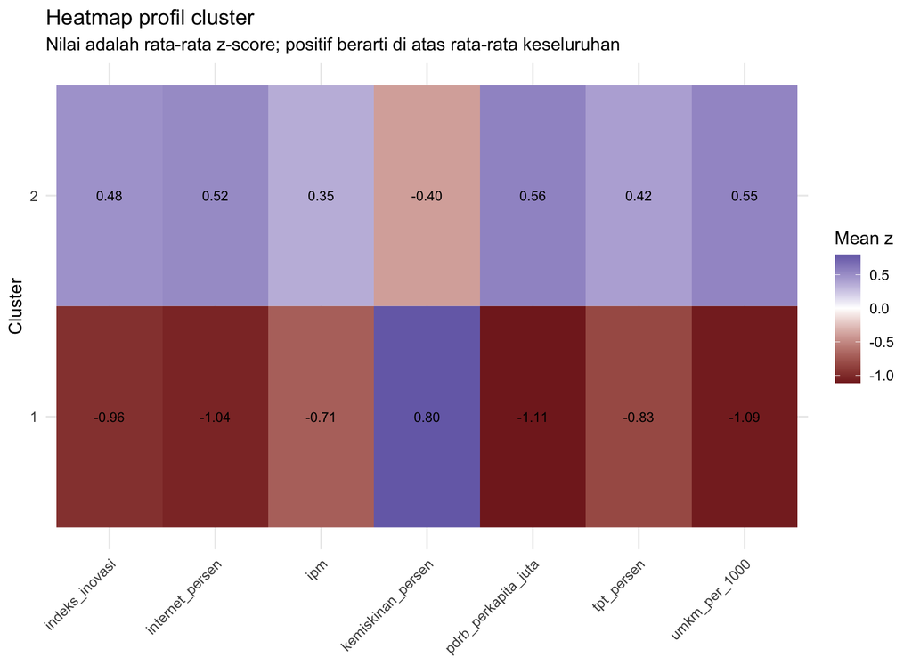

```r
profile_z11 <- as.data.frame(X11) |>
  dplyr::mutate(cluster = factor(km11$cluster)) |>
  dplyr::group_by(cluster) |>
  dplyr::summarise(dplyr::across(dplyr::everything(), mean), .groups = "drop") |>
  tidyr::pivot_longer(-cluster, names_to = "indikator", values_to = "mean_z")

ggplot2::ggplot(profile_z11, ggplot2::aes(indikator, cluster, fill = mean_z)) +
  ggplot2::geom_tile() +
  ggplot2::geom_text(ggplot2::aes(label = sprintf("%.2f", mean_z)), size = 3.2) +
  ggplot2::scale_fill_gradient2(midpoint = 0) +
  ggplot2::labs(title = "Heatmap profil cluster", subtitle = "Nilai adalah rata-rata z-score; positif berarti di atas rata-rata keseluruhan", x = NULL, y = "Cluster", fill = "Mean z") +
  ggplot2::theme(axis.text.x = ggplot2::element_text(angle = 45, hjust = 1))
```

Heatmap lebih berguna untuk penamaan cluster daripada centroid mentah karena seluruh indikator telah berada pada skala yang sebanding.

## 11.8 Silhouette Setiap Wilayah

```r
sil11 <- cluster::silhouette(km11$cluster, d11)
sil_tbl11 <- tibble::as_tibble(as.data.frame(sil11)) |>
  dplyr::mutate(wilayah = reg11$wilayah) |>
  dplyr::arrange(sil_width)

knitr::kable(
  sil_tbl11 |> dplyr::select(wilayah, cluster, neighbor, sil_width),
  digits = 3,
  caption = "Silhouette setiap wilayah; nilai rendah/negatif perlu diperiksa"
)
```

Table 11.7: Silhouette setiap wilayah; nilai rendah/negatif perlu diperiksa

| wilayah | cluster | neighbor | sil_width |
| --- | --- | --- | --- |
| Wilayah_07 | 2 | 1 | 0.037 |
| Wilayah_17 | 1 | 2 | 0.171 |
| Wilayah_26 | 2 | 1 | 0.213 |
| Wilayah_09 | 2 | 1 | 0.252 |
| Wilayah_27 | 2 | 1 | 0.252 |
| Wilayah_13 | 2 | 1 | 0.254 |
| Wilayah_04 | 2 | 1 | 0.278 |
| Wilayah_05 | 2 | 1 | 0.280 |
| Wilayah_18 | 2 | 1 | 0.302 |
| Wilayah_03 | 2 | 1 | 0.319 |
| Wilayah_16 | 2 | 1 | 0.344 |
| Wilayah_23 | 1 | 2 | 0.362 |
| Wilayah_06 | 1 | 2 | 0.367 |
| Wilayah_24 | 2 | 1 | 0.381 |
| Wilayah_20 | 2 | 1 | 0.389 |
| Wilayah_02 | 2 | 1 | 0.389 |
| Wilayah_25 | 1 | 2 | 0.456 |
| Wilayah_11 | 2 | 1 | 0.456 |
| Wilayah_08 | 1 | 2 | 0.456 |
| Wilayah_12 | 2 | 1 | 0.472 |
| Wilayah_21 | 1 | 2 | 0.483 |
| Wilayah_14 | 2 | 1 | 0.489 |
| Wilayah_10 | 2 | 1 | 0.494 |
| Wilayah_01 | 1 | 2 | 0.511 |
| Wilayah_22 | 2 | 1 | 0.520 |
| Wilayah_15 | 1 | 2 | 0.560 |
| Wilayah_19 | 1 | 2 | 0.568 |

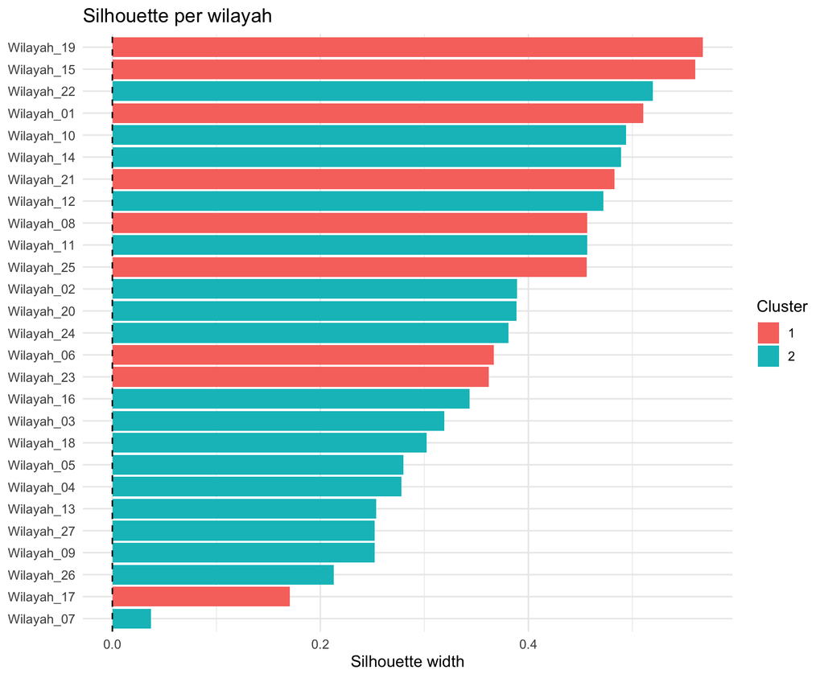

```r
ggplot2::ggplot(sil_tbl11, ggplot2::aes(reorder(wilayah, sil_width), sil_width, fill = factor(cluster))) +
  ggplot2::geom_col() +
  ggplot2::coord_flip() +
  ggplot2::geom_hline(yintercept = 0, linetype = 2) +
  ggplot2::labs(title = "Silhouette per wilayah", x = NULL, y = "Silhouette width", fill = "Cluster")
```

Wilayah dengan silhouette dekat nol adalah kasus transisi; kebijakan sebaiknya tidak memperlakukan batas cluster sebagai kategori keras.

## 11.9 Visualisasi Cluster pada Ruang PCA

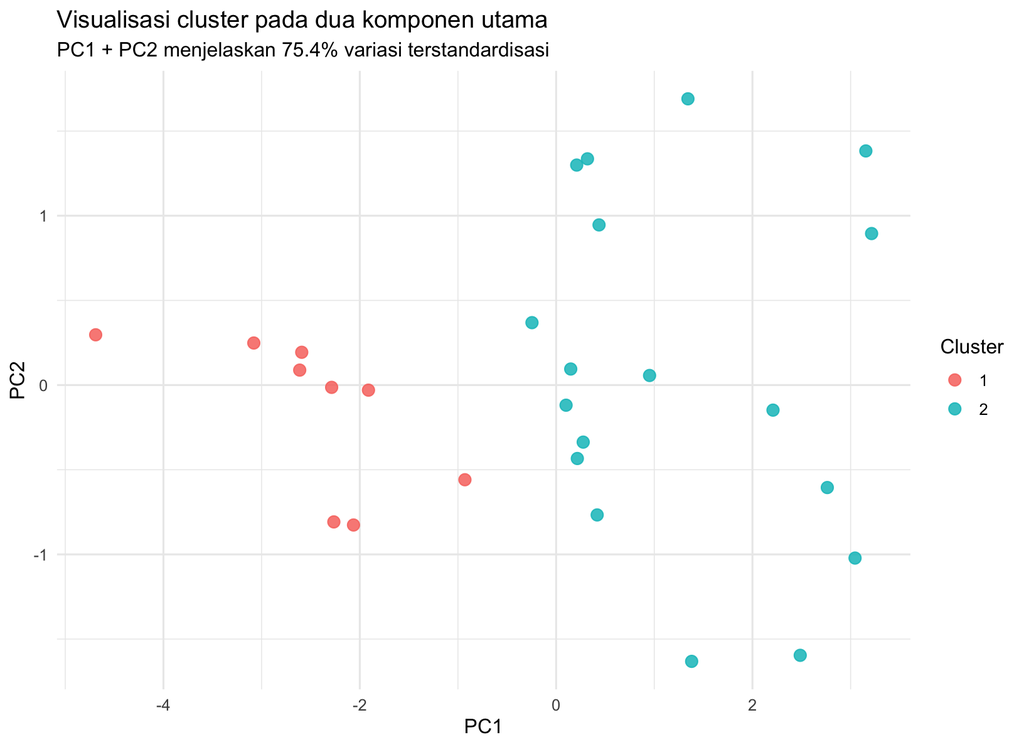

```r
pca11 <- stats::prcomp(X11, center = FALSE, scale. = FALSE)
pca_score11 <- tibble::as_tibble(pca11$x[, 1:2]) |>
  dplyr::mutate(wilayah = reg11$wilayah, cluster = factor(km11$cluster))

ggplot2::ggplot(pca_score11, ggplot2::aes(PC1, PC2, colour = cluster)) +
  ggplot2::geom_point(size = 3, alpha = .85) +
  ggplot2::labs(
    title = "Visualisasi cluster pada dua komponen utama",
    subtitle = paste0("PC1 + PC2 menjelaskan ", round(100 * sum(summary(pca11)$importance[2,1:2]), 1), "% variasi terstandardisasi"),
    colour = "Cluster"
  )
```

Plot PCA hanya proyeksi dua dimensi; keputusan K-means tetap menggunakan seluruh indikator terstandardisasi, bukan hanya PC1–PC2.

## 11.10 Pembanding: Hierarchical Clustering Ward

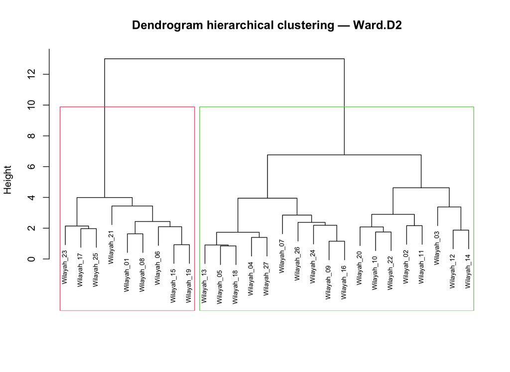

```r
hc11 <- stats::hclust(d11, method = "ward.D2")
plot(hc11, labels = reg11$wilayah, cex = .65,
     main = "Dendrogram hierarchical clustering — Ward.D2", xlab = "", sub = "")
rect.hclust(hc11, k = k11, border = 2:(k11 + 1))
```

```r
hc_group11 <- stats::cutree(hc11, k = k11)
agreement11 <- table(KMeans = km11$cluster, Ward = hc_group11)
knitr::kable(as.data.frame.matrix(agreement11), caption = "Tabulasi silang K-means versus Ward")
```

Table 11.8: Tabulasi silang K-means versus Ward

| 1 | 2 |
| --- | --- |
| 9 | 0 |
| 0 | 18 |

## 11.11 Interpretasi dalam Konteks Regional

Cluster tidak membuktikan mekanisme sebab-akibat. Setelah tipologi terbentuk, mahasiswa harus kembali ke data sektoral, konteks institusi, dan informasi lapangan untuk memeriksa apakah paket kebijakan yang diusulkan masuk akal.

## 11.12 Latihan

1. Mengapa K-means perlu standardisasi ketika unit indikator berbeda?
2. Apa perbedaan informasi yang diberikan elbow plot dan silhouette?
3. Mengapa cluster dengan silhouette negatif perlu diperiksa?
4. Ulangi analisis dengan mengeluarkan satu indikator yang sangat berkorelasi. Bandingkan profil dan membership.
5. Bandingkan $K=3$, $K=4$, dan $K=5$. Apakah rekomendasi kebijakan berubah secara substantif?
6. Buat nama deskriptif untuk setiap cluster tanpa menggunakan istilah normatif seperti “buruk”, “gagal”, atau “tertinggal”.

### 11.12.1 Tugas Terstruktur Pertemuan 11

Gunakan 5–8 indikator pada capstone project. Tampilkan **statistik deskriptif, korelasi, alasan standardisasi, evaluasi $K$, tabel membership lengkap, profil cluster, silhouette, heatmap, dan minimal satu sensitivity check**. Akhiri dengan satu halaman strategi kebijakan yang berbeda untuk setiap tipologi.

### 11.12.2 Kuis Formatif Pertemuan 11

1. Tuliskan fungsi objektif K-means.
2. Apa makna $s(i)<0$ pada silhouette?
3. Mengapa WSS selalu turun ketika $K$ bertambah?
4. Apa implikasi dua indikator yang hampir redundan terhadap Euclidean distance?
5. Mengapa cluster tidak boleh ditafsirkan sebagai kelas sosial yang “alamiah”?

## 11.13 Hubungan dengan Capstone Project

Milestone minggu ini adalah **regional segmentation package**: fitur terpilih, hasil evaluasi $K$, membership, profil, visualisasi, sensitivity analysis, dan satu set rekomendasi berbeda menurut tipologi.

## 11.14 Kesimpulan

Clustering bernilai ketika ia mengubah data multivariat menjadi tipologi yang dapat dipahami dan diuji. Analisis yang hanya menghasilkan nomor cluster tanpa profil, silhouette, membership, dan sensitivity check belum cukup untuk jenjang magister.

## 11.15 Pendalaman Magister — Clustering dan Regional Typology

### 11.15.1 Audit metodologis

1. Apakah pilihan indikator memiliki justifikasi substantif?
2. Apakah standardisasi dan distance metric sesuai?
3. Apakah $K$ dipilih dari lebih dari satu bukti?
4. Apakah cluster stabil terhadap perubahan seed, fitur, dan metode?
5. Apakah label cluster bersifat deskriptif dan non-stigmatis?
6. Apakah rekomendasi dibangun dari profil indikator, bukan nomor cluster semata?

### 11.15.2 Pertanyaan Viva

1. Apa yang sebenarnya diminimumkan K-means?
2. Mengapa silhouette dapat negatif?
3. Kapan Ward memberi hasil berbeda dari K-means?
4. Mengapa PCA plot tidak identik dengan ruang clustering penuh?
5. Bagaimana Anda menjelaskan ketidakstabilan cluster kepada pembuat kebijakan?

# 12 Dimension Reduction dan PCA untuk Indikator Pembangunan

## 12.1 Pendahuluan

Indikator pembangunan sering saling berkorelasi: pendidikan, kesehatan, internet, pendapatan, dan layanan dasar bergerak bersama. PCA membantu mereduksi dimensi dan mengidentifikasi kombinasi laten, tetapi komponen harus ditafsirkan dengan hati-hati.

## 12.2 Tujuan Pembelajaran

Mahasiswa mampu melakukan PCA pada data yang distandardisasi, membaca variance explained dan loadings, serta menggunakan komponen untuk visualisasi/segmentasi tanpa kehilangan interpretasi kebijakan.

## 12.3 Definisi dan Konsep

PCA mencari arah linear yang menjelaskan variasi maksimum. PC1 adalah kombinasi linear dengan variance terbesar, PC2 orthogonal terhadap PC1 dan menjelaskan variance terbesar berikutnya. PCA tidak secara otomatis menghasilkan “indeks pembangunan” yang normatif.

## 12.4 Formulasi Matematis

Untuk data terpusat $\mathbf X$, covariance matrix

$$\mathbf S=\frac{1}{n-1}\mathbf X^\top\mathbf X.$$

PCA menyelesaikan

$$\mathbf S\mathbf v_k=\lambda_k\mathbf v_k,$$

di mana $\mathbf v_k$ eigenvector/loading PC ke-$k$ dan $\lambda_k$ variance yang dijelaskan. Skor komponen:

$$z_{ik}=\mathbf x_i^\top\mathbf v_k.$$

### 12.4.1 Matriks data terpusat dan covariance

Untuk data $X$ berukuran $n\times p$, pusatkan setiap kolom:
$$X_c=X-\mathbf 1\bar x'.$$
Covariance matrix:
$$S=\frac{1}{n-1}X_c'X_c.$$
Jika variabel memiliki unit/skala sangat berbeda, gunakan correlation PCA dengan data standardisasi $Z$.

### 12.4.2 Eigen decomposition

PCA mencari arah unit $v_k$ yang memaksimalkan variance proyeksi:
$$v_1=\arg\max_{\|v\|=1}Var(X_cv).$$
Solusinya adalah eigenvector dari $S$:
$$Sv_k=\lambda_kv_k,$$
dengan $\lambda_1\ge\lambda_2\ge\cdots\ge0$.

Score principal component:
$$z_{ik}=x_{ic}'v_k.$$
Loading $v_{jk}$ menunjukkan kontribusi variabel $j$ pada komponen $k$.

### 12.4.3 Explained variance

$$PVE_k=\frac{\lambda_k}{\sum_{j=1}^{p}\lambda_j},$$
$$CPVE_K=\sum_{k=1}^{K}PVE_k.$$
Pemilihan jumlah komponen tidak boleh hanya berdasarkan threshold 80%/90%; interpretability dan tujuan project harus dipertimbangkan. (Jolliffe dan Cadima 2016)

### 12.4.4 Rekonstruksi dan information loss

Dengan $K<p$ komponen:
$$\widehat X_c=Z_KV_K'.$$
Reconstruction error:
$$E_K=\|X_c-\widehat X_c\|_F^2.$$
PCA memilih subspace linear yang meminimalkan squared reconstruction error, tetapi komponen yang menjelaskan variance tinggi belum tentu paling relevan untuk outcome kebijakan tertentu.

### 12.4.5 PCA untuk indeks regional: peluang dan batasan

Skor PC1 dapat dipakai sebagai *data-driven index*:
$$PC1_i=\sum_j v_{j1}z_{ij}.$$
Namun tanda eigenvector dapat terbalik tanpa mengubah solusi; orientasi indeks harus ditentukan agar “lebih tinggi” memiliki arti substantif konsisten. PCA juga menimbang berdasarkan struktur covariance, bukan prioritas normatif. Bandingkan dengan indeks berbobot teori dan lakukan sensitivity analysis. (OECD dan Joint Research Centre, European Commission 2008)

### 12.4.6 Biplot interpretation

Sudut antar loading vector secara kasar berkaitan dengan korelasi: arah sejalan ≈ korelasi positif, berlawanan ≈ negatif, hampir tegak lurus ≈ korelasi kecil. Panjang dan skala biplot bergantung implementasi, jadi interpretasi harus mengikuti definisi scaling perangkat lunak.

## 12.5 Intuisi Metode

Jika internet, IPM, pendidikan, dan akses kesehatan semuanya tinggi bersama, PC1 dapat menangkap “kapabilitas layanan/manusia” secara statistik. Tetapi penamaan tersebut harus didukung pola loading, bukan asumsi.

### 12.5.1 Worked Example — PCA dua variabel

Misalkan covariance matrix standardized dua indikator adalah
$$S=\begin{bmatrix}1&0.8\\0.8&1\end{bmatrix}.$$
Eigenvalue memenuhi $|S-\lambda I|=0$:
$$(1-\lambda)^2-0.64=0 \Rightarrow \lambda_1=1.8,\;\lambda_2=0.2.$$
Total variance=2, sehingga
$$PVE_1=1.8/2=90\%,\qquad PVE_2=10\%.$$
Eigenvector pertama proporsional $(1,1)$, artinya PC1 kira-kira rata-rata standardized kedua indikator; PC2 menangkap kontras di antara keduanya.

### 12.5.2 Loading sign ambiguity

Jika $v$ adalah eigenvector, $-v$ juga eigenvector dengan eigenvalue sama. Karena itu software dapat memberikan PC1 dengan tanda berlawanan tanpa mengubah geometri. Untuk indeks, pilih orientasi agar makna substantif konsisten dan dokumentasikan pembalikan tanda.

### 12.5.3 Correlation PCA vs covariance PCA

Jika variabel berbeda unit, covariance PCA dapat didominasi variabel variance besar. Correlation PCA ekuivalen PCA pada $Z$ standardized. Namun standardisasi menganggap satu SD setiap variabel comparable; jika measurement reliability berbeda, pertimbangkan hal tersebut dalam interpretasi.

### 12.5.4 Reconstruction intuition

Dengan $K$ komponen, prediksi data standardized:
$$\hat z_i=\sum_{k=1}^{K}score_{ik}v_k.$$
Residual reconstruction $z_i-\hat z_i$ menunjukkan informasi yang tidak ditangkap komponen. Wilayah dengan reconstruction error tinggi bisa merupakan pola unik/outlier yang justru penting secara kebijakan.

### 12.5.5 R output reading

```r
xp <- panel |> filter(tahun==2025) |>
  select(kemiskinan_persen, tpt_persen, internet_persen, ipm, indeks_inovasi)
pca <- prcomp(xp, center=TRUE, scale.=TRUE)
summary(pca)
```

```
#> Importance of components:
#>                           PC1    PC2    PC3    PC4     PC5
#> Standard deviation     1.7221 0.8432 0.7656 0.6708 0.53601
#> Proportion of Variance 0.5931 0.1422 0.1172 0.0900 0.05746
#> Cumulative Proportion  0.5931 0.7353 0.8525 0.9425 1.00000
```

```r
round(pca$rotation[,1:3],3)
```

```
#>                      PC1    PC2    PC3
#> kemiskinan_persen -0.443 -0.003 -0.696
#> tpt_persen         0.367  0.893 -0.190
#> internet_persen    0.501 -0.108  0.215
#> ipm                0.439 -0.217 -0.645
#> indeks_inovasi     0.475 -0.379 -0.133
```

Baca `sdev^2` sebagai eigenvalue (untuk covariance matrix dari data transformed sesuai `prcomp`), `rotation` sebagai loading/eigenvectors, dan `x` sebagai score.

### 12.5.6 PCA vs index theory

Jika PC1 memberi loading besar pada internet dan IPM karena variance/correlation dominan, tetapi stakeholder menilai akses kesehatan normatif sangat penting, PC1 tidak otomatis menggantikan indeks teori. Laporkan dua pendekatan dan sensitivitas. (Jolliffe dan Cadima 2016; OECD dan Joint Research Centre, European Commission 2008)

## 12.6 Contoh dengan Data Simulasi

```r
reg <- read_csv("data/simulasi_panel_regional.csv", show_col_types = FALSE) |>
  filter(tahun == 2025)
X <- reg |> select(ipm, internet_persen, indeks_pendidikan, akses_kesehatan, pdrb_perkapita_juta, umkm_per_1000)
pca <- prcomp(X, center = TRUE, scale. = TRUE)
summary(pca)
```

```
#> Importance of components:
#>                           PC1    PC2     PC3     PC4     PC5     PC6
#> Standard deviation     2.0253 0.8835 0.72790 0.58744 0.39925 0.28818
#> Proportion of Variance 0.6837 0.1301 0.08831 0.05751 0.02657 0.01384
#> Cumulative Proportion  0.6837 0.8138 0.90208 0.95959 0.98616 1.00000
```

```r
round(pca$rotation[, 1:3], 3) |> knitr::kable(caption = "Loading tiga komponen utama")
```

Table 12.1: Loading tiga komponen utama

|  | PC1 | PC2 | PC3 |
| --- | --- | --- | --- |
| ipm | 0.400 | 0.240 | 0.544 |
| internet_persen | 0.417 | -0.503 | 0.002 |
| indeks_pendidikan | 0.402 | 0.401 | 0.345 |
| akses_kesehatan | 0.347 | 0.597 | -0.633 |
| pdrb_perkapita_juta | 0.454 | -0.267 | 0.087 |
| umkm_per_1000 | 0.422 | -0.318 | -0.420 |

## 12.7 Contoh dengan Data Nyata

INDO-DAPOER menyediakan banyak indikator yang secara substantif saling terkait. Sebelum PCA, pilih satu periode dan pastikan kelengkapan data memadai. Jangan mencampur level provinsi dan kabupaten atau indikator dengan tahun berbeda tanpa justifikasi.

**Kartu dataset real.**

- **Nama:** indikator multivariat pembangunan INDO-DAPOER untuk PCA.
- **Sumber dan URL:** World Bank Data Catalog, https://datacatalog.worldbank.org/search/dataset/0041056/indonesia-database-for-policy-and-economic-research.
- **Tahun:** satu tahun analisis ≤2018 dengan overlap indikator memadai.
- **Unit observasi:** kabupaten/kota.
- **Variabel/definisi:** sekumpulan indikator kuantitatif pembangunan (mis. poverty, literacy, HDI components, fiscal/infrastructure indicators); transformasi/standardisasi dicatat eksplisit.
- **Alasan digunakan:** menunjukkan bagaimana korelasi antarindikator dapat diringkas menjadi beberapa komponen tanpa menyebutnya otomatis sebagai indeks kebijakan.
- **Keterbatasan:** PCA sensitif terhadap skala/outlier dan hanya menangkap variasi linear; komponen tinggi varian belum tentu paling relevan bagi kebijakan. (World Bank 2026)

## 12.8 Analisis Menggunakan R

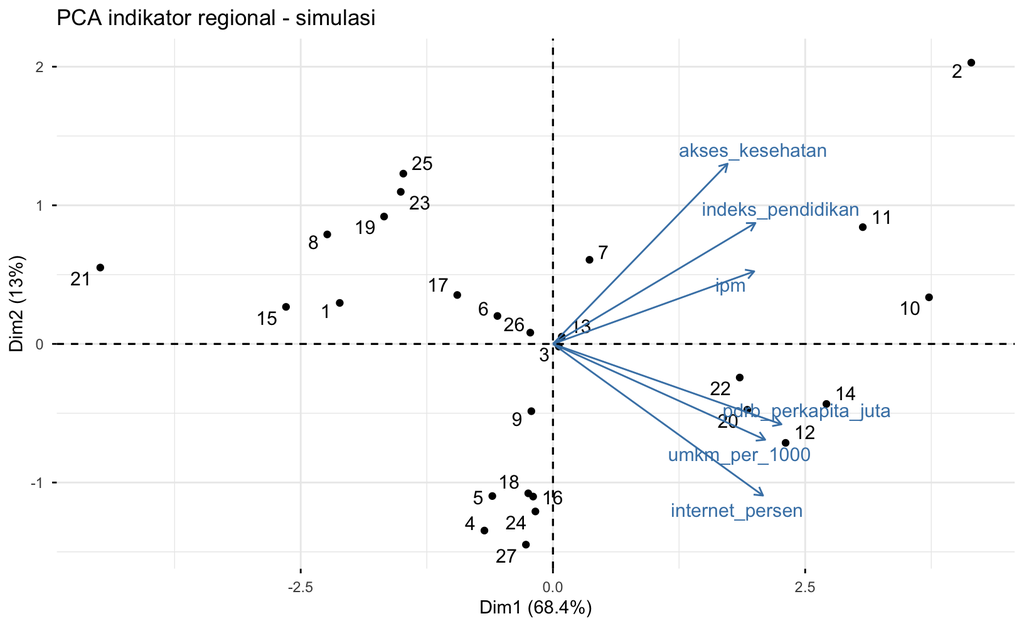

```r
library(factoextra)
fviz_pca_biplot(pca, repel = TRUE, title = "PCA indikator regional - simulasi")
```

## 12.9 Paket Output PCA Lengkap

```r
eigen12 <- pca$sdev^2
pve12 <- eigen12/sum(eigen12)
eigen_tbl12 <- tibble::tibble(
  PC=paste0("PC",seq_along(eigen12)), eigenvalue=eigen12,
  PVE=pve12, cumulative_PVE=cumsum(pve12)
)
knitr::kable(eigen_tbl12, digits=3, caption="Eigenvalue, proportion variance explained, dan kumulatif")
```

Table 12.2: Eigenvalue, proportion variance explained, dan kumulatif

| PC | eigenvalue | PVE | cumulative_PVE |
| --- | --- | --- | --- |
| PC1 | 4.102 | 0.684 | 0.684 |
| PC2 | 0.781 | 0.130 | 0.814 |
| PC3 | 0.530 | 0.088 | 0.902 |
| PC4 | 0.345 | 0.058 | 0.960 |
| PC5 | 0.159 | 0.027 | 0.986 |
| PC6 | 0.083 | 0.014 | 1.000 |

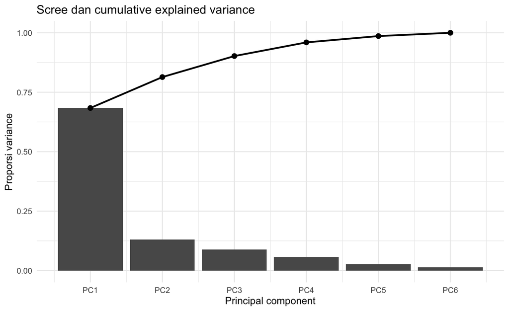

```r
ggplot2::ggplot(eigen_tbl12, ggplot2::aes(seq_along(eigenvalue), PVE)) +
  ggplot2::geom_col() + ggplot2::geom_line(ggplot2::aes(y=cumulative_PVE), linewidth=1) +
  ggplot2::geom_point(ggplot2::aes(y=cumulative_PVE), size=2.5) +
  ggplot2::scale_x_continuous(breaks=seq_along(eigen12), labels=eigen_tbl12$PC) +
  ggplot2::labs(title="Scree dan cumulative explained variance", x="Principal component", y="Proporsi variance")
```

```r
load12 <- as.data.frame(pca$rotation[,1:min(4,ncol(pca$rotation)),drop=FALSE]) |>
  tibble::rownames_to_column("indikator")
knitr::kable(load12, digits=3, caption="Loading komponen utama")
```

Table 12.3: Loading komponen utama

| indikator | PC1 | PC2 | PC3 | PC4 |
| --- | --- | --- | --- | --- |
| ipm | 0.400 | 0.240 | 0.544 | -0.623 |
| internet_persen | 0.417 | -0.503 | 0.002 | 0.394 |
| indeks_pendidikan | 0.402 | 0.401 | 0.345 | 0.595 |
| akses_kesehatan | 0.347 | 0.597 | -0.633 | -0.004 |
| pdrb_perkapita_juta | 0.454 | -0.267 | 0.087 | -0.042 |
| umkm_per_1000 | 0.422 | -0.318 | -0.420 | -0.318 |

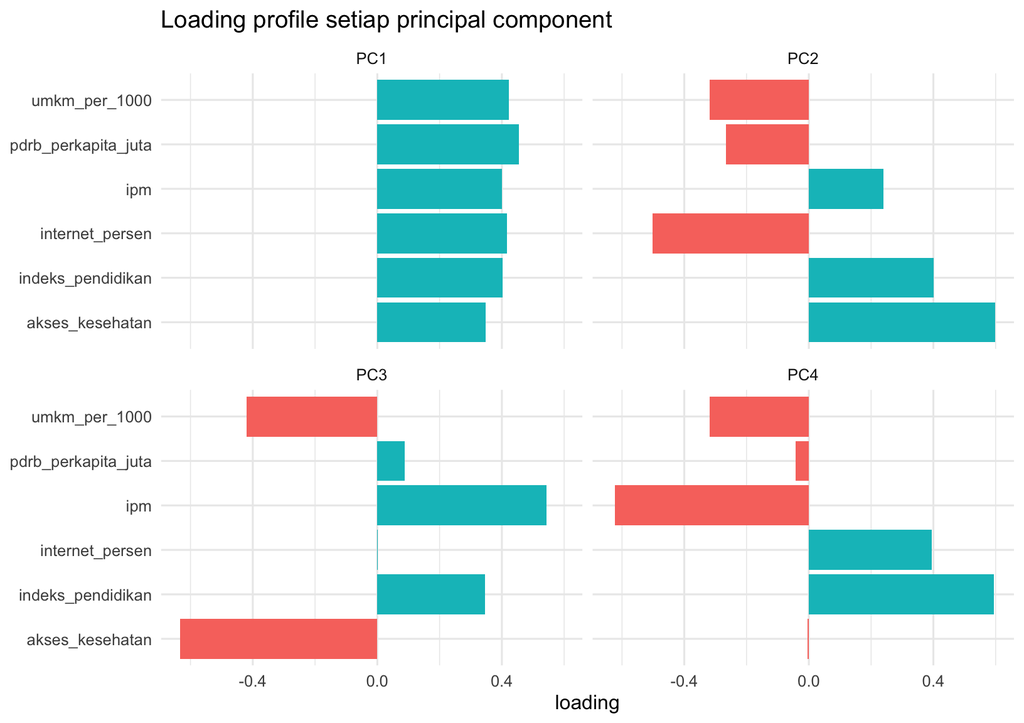

```r
load_long12 <- load12 |> tidyr::pivot_longer(-indikator, names_to="PC", values_to="loading")
ggplot2::ggplot(load_long12, ggplot2::aes(indikator, loading, fill=loading>0)) +
  ggplot2::geom_col(show.legend=FALSE) + ggplot2::facet_wrap(~PC) +
  ggplot2::coord_flip() + ggplot2::labs(title="Loading profile setiap principal component", x=NULL)
```

```r
score12 <- tibble::as_tibble(pca$x[,1:2,drop=FALSE]) |> dplyr::mutate(wilayah=reg$wilayah) |>
  dplyr::select(wilayah, dplyr::everything()) |> dplyr::arrange(dplyr::desc(PC1))
knitr::kable(score12, digits=3, caption="Score PC1 dan PC2 setiap wilayah")
```

Table 12.4: Score PC1 dan PC2 setiap wilayah

| wilayah | PC1 | PC2 |
| --- | --- | --- |
| Wilayah_02 | 4.146 | 2.029 |
| Wilayah_10 | 3.727 | 0.336 |
| Wilayah_11 | 3.071 | 0.842 |
| Wilayah_14 | 2.711 | -0.433 |
| Wilayah_12 | 2.306 | -0.714 |
| Wilayah_20 | 1.926 | -0.475 |
| Wilayah_22 | 1.851 | -0.243 |
| Wilayah_07 | 0.362 | 0.607 |
| Wilayah_13 | 0.087 | 0.052 |
| Wilayah_03 | 0.059 | -0.019 |
| Wilayah_24 | -0.174 | -1.209 |
| Wilayah_16 | -0.196 | -1.101 |
| Wilayah_09 | -0.214 | -0.485 |
| Wilayah_26 | -0.225 | 0.081 |
| Wilayah_18 | -0.245 | -1.078 |
| Wilayah_27 | -0.268 | -1.448 |
| Wilayah_06 | -0.550 | 0.202 |
| Wilayah_05 | -0.601 | -1.098 |
| Wilayah_04 | -0.679 | -1.347 |
| Wilayah_17 | -0.948 | 0.353 |
| Wilayah_25 | -1.483 | 1.228 |
| Wilayah_23 | -1.508 | 1.097 |
| Wilayah_19 | -1.673 | 0.919 |
| Wilayah_01 | -2.113 | 0.296 |
| Wilayah_08 | -2.237 | 0.790 |
| Wilayah_15 | -2.646 | 0.267 |
| Wilayah_21 | -4.486 | 0.551 |

## 12.10 Interpretasi dalam Konteks Regional

Jika PC1 memberi loading positif tinggi pada IPM, internet, pendidikan, kesehatan, dan PDRB, skor PC1 tinggi dapat dibaca sebagai kombinasi kapabilitas pembangunan. Namun PCA memaksimalkan variance, bukan relevansi kebijakan; indikator penting dengan variasi kecil dapat terabaikan.

## 12.11 Latihan

1. Mengapa PCA biasanya membutuhkan standardisasi?
2. Apa arti eigenvalue besar?
3. Mengapa PC1 bukan otomatis “indeks pembangunan terbaik”?
4. **Analisis:** tentukan jumlah PC untuk menjelaskan minimal 80% variance.
5. **Analisis:** gunakan PC1-PC2 sebagai input clustering dan bandingkan hasil.
6. **Mini-case:** pimpinan meminta satu indeks komposit. Jelaskan kapan PCA layak dan kapan pendekatan berbobot kebijakan lebih tepat.

### 12.11.1 Tugas Terstruktur Pertemuan 12

Lakukan PCA pada minimal lima indikator regional. Laporkan eigenvalues, PVE, loading, score, dan biplot. Bandingkan ranking berbasis PC1 dengan indeks berbobot teori. Jelaskan minimal dua perbedaan dan implikasinya.

### 12.11.2 Kuis Formatif Pertemuan 12

Fokus: covariance vs correlation PCA; eigenvalue/eigenvector; score/loading; PVE; reconstruction; tanda PC; keterbatasan PCA untuk indeks kebijakan.

## 12.12 Hubungan dengan Capstone Project

PCA dapat dipakai bila proyek memiliki banyak indikator berkorelasi atau untuk membangun visual 2D sebelum clustering. Tim harus tetap menyertakan tabel loading dan interpretasi.

## 12.13 Kesimpulan

PCA mereduksi kompleksitas statistik, bukan kompleksitas kebijakan. Komponen harus dibaca melalui loadings, variance explained, dan konteks indikator.

## 12.14 Pendalaman Magister — PCA dan konstruksi indeks

### 12.14.1 Audit metodologis

1. Pca covariance dipakai pada unit tak sebanding.
2. Pc1 disebut indeks terbaik otomatis.
3. Loading sign disalahartikan.
4. Pve tinggi dianggap policy relevance.
5. Outlier mendominasi covariance.
6. Pca dihitung sebelum split pada predictive workflow.

### 12.14.2 Pertanyaan viva / diskusi kelas

1. Apa eigenvalue dan eigenvector secara substantif?
2. Mengapa scaling penting?
3. Apa beda score dan loading?
4. Mengapa tanda PC dapat dibalik?
5. Bagaimana memilih K komponen?
6. Mengapa PCA dan indeks normatif harus dibandingkan?

# 13 Analisis Data Spasial Areal dan Visualisasi Geospasial

## 13.1 Pendahuluan

Analisis regional pada tingkat kabupaten/kota secara alami merupakan **data areal**: setiap observasi mewakili suatu polygon administratif, bukan satu titik koordinat. Karena itu pembelajaran spasial pada bab ini menggunakan batas kabupaten/kota Jawa Barat dari berkas polygon yang disediakan bersama e-book dan menggabungkannya dengan **persentase penduduk miskin tahun 2024**. Dataset kemiskinan kabupaten/kota Jawa Barat dipublikasikan oleh Badan Pusat Statistik dan didiseminasikan melalui Open Data Jawa Barat; seri persentase tersedia untuk 2010–2025, sedangkan publikasi resmi BPS Jawa Barat juga mendokumentasikan kemiskinan kabupaten/kota 2019–2024. (Badan Pusat Statistik dan Pemerintah Provinsi Jawa Barat 2026c; Badan Pusat Statistik Provinsi Jawa Barat 2025)

Bab ini membahas tiga lapis analisis: **(1) pemetaan choropleth, (2) pembentukan struktur ketetanggaan areal, dan (3) autocorrelation global serta lokal**. Peta sendiri hanya menunjukkan lokasi nilai; statistik spasial diperlukan untuk menilai apakah wilayah dengan nilai serupa cenderung berdekatan. (Moran 1950; Anselin 1995; Bivand, Pebesma, dan Gómez-Rubio 2013; Pebesma dan Bivand 2023)

## 13.2 Tujuan Pembelajaran

Setelah pertemuan ini mahasiswa mampu:

1. membedakan data point, line, dan areal/polygon;
2. membaca dan memeriksa geometri polygon dengan `sf`;
3. menggabungkan indikator kemiskinan dengan polygon berdasarkan kode wilayah;
4. menyusun matriks bobot spasial dari hubungan antar-polygon dan kedekatan batas wilayah;
5. menghitung spatial lag dan Moran’s $I$;
6. melakukan permutation test untuk autocorrelation global;
7. menghitung Local Moran dan memetakan pola High–High, Low–Low, High–Low, dan Low–High;
8. melakukan sensitivity analysis terhadap definisi neighborhood areal; dan
9. menjelaskan MAUP serta ecological fallacy dalam rekomendasi regional.

## 13.3 Konsep Data Areal

Misalkan Jawa Barat dibagi menjadi $n$ wilayah administratif. Untuk setiap polygon $A_i$ diamati outcome $y_i$, misalnya persentase penduduk miskin. Dua wilayah disebut bertetangga bila polygon mereka memenuhi aturan tertentu.

Secara klasik, **Queen contiguity** menyatakan dua polygon bertetangga bila berbagi sisi atau titik sudut, sedangkan **Rook contiguity** mensyaratkan sisi bersama. Namun shapefile administratif dapat memiliki overlap, enclave, atau ketidaksempurnaan topologi. Karena itu pada contoh ini bobot utama dibangun dari **hubungan intersection antar-polygon**:

$$w_{ij}=\begin{cases}
1, & A_i\cap A_j\neq\varnothing,\\
0, & \text{lainnya},
\end{cases}$$

untuk $i\neq j$. Sebagai sensitivity analysis, digunakan bobot kedua berbasis **jarak minimum antar-polygon** sampai 10 km. Ini tetap merupakan analisis areal karena jarak dihitung dari geometry polygon, bukan mengganti wilayah menjadi data point. Matriks bobot $\mathbf W=[w_{ij}]$ kemudian di-*row-standardize*:

$$w_{ij}^{*}=\frac{w_{ij}}{\sum_j w_{ij}},$$

sehingga spatial lag untuk wilayah $i$ adalah rata-rata tertimbang nilai tetangganya:

$$(Wy)_i=\sum_j w_{ij}^{*}y_j.$$

## 13.4 Moran’s I Global

Definisikan deviasi dari rata-rata $z_i=y_i-\bar y$. Moran’s $I$ adalah

$$I=\frac{n}{S_0}
\frac{\sum_i\sum_j w_{ij}z_i z_j}
{\sum_i z_i^2},$$

dengan

$$S_0=\sum_i\sum_j w_{ij}.$$

Secara umum, $I>0$ menunjukkan nilai serupa cenderung berdekatan, $I<0$ menunjukkan pola tetangga yang kontras, dan nilai dekat ekspektasi acak menunjukkan tidak ada autocorrelation yang kuat. Interpretasi tidak boleh hanya berdasarkan tanda; gunakan randomization/permutation inference. (Moran 1950)

Jika $I^{(1)},\ldots,I^{(B)}$ adalah Moran’s $I$ dari $B$ permutasi label wilayah, pseudo p-value dapat dihitung dari proporsi statistik permutasi yang sama atau lebih ekstrem daripada nilai observasi, dengan koreksi Monte Carlo.

## 13.5 Local Moran dan LISA

Local Moran untuk wilayah $i$ dapat ditulis

$$I_i=\frac{z_i}{m_2}\sum_j w_{ij}z_j,$$

dengan

$$m_2=\frac{1}{n}\sum_i z_i^2.$$

Gabungan tanda $z_i$ dan spatial lag menghasilkan empat pola:

- **High–High (HH):** nilai tinggi dikelilingi nilai tinggi;
- **Low–Low (LL):** nilai rendah dikelilingi nilai rendah;
- **High–Low (HL):** nilai tinggi di antara tetangga rendah;
- **Low–High (LH):** nilai rendah di antara tetangga tinggi.

LISA bersifat lokal dan melibatkan banyak pengujian. Peta LISA harus dibaca sebagai **screening pola lokal**, bukan bukti kausal. (Anselin 1995)

## 13.6 Dataset dan Provenance

**Geometry.** Folder `data/spatial_jabar/` berasal dari ZIP batas administratif yang diberikan untuk mata kuliah. Berkas utama adalah `JABAR.shp`, `JABAR.shx`, dan `JABAR.dbf`. Shapefile tidak menyertakan `.prj`, sehingga CRS tidak tersimpan secara eksplisit. Koordinat berada pada rentang longitude–latitude Jawa Barat; dalam latihan ini CRS ditetapkan sebagai EPSG:4326 setelah pemeriksaan. Pada riset nyata, CRS wajib diverifikasi pada sumber geodata sebelum penetapan manual.

**Outcome.** File `data/kemiskinan_jabar_2024.csv` berisi persentase penduduk miskin 27 kabupaten/kota Jawa Barat tahun 2024 dan disiapkan sebagai *teaching extract* dari seri BPS/Open Data Jawa Barat. Portal resminya mendokumentasikan variabel kabupaten/kota, persentase penduduk miskin, satuan persen, dan tahun; publikasi BPS Jawa Barat 2019–2024 menjadi rujukan substantif tambahan untuk konteks indikator kemiskinan. (Badan Pusat Statistik dan Pemerintah Provinsi Jawa Barat 2026c; Badan Pusat Statistik Provinsi Jawa Barat 2025)

**Catatan join.** Geometry lama pada kode 18 masih dapat membawa label historis yang tidak konsisten. Karena itu join dilakukan dengan `KABKOTNO`, lalu nama tampilan diambil dari tabel kemiskinan. Ini menunjukkan mengapa kode wilayah lebih aman daripada fuzzy matching nama.

## 13.7 Import Polygon dan Audit Geometry

```r
jabar13 <- sf::st_read("data/spatial_jabar/JABAR.shp", quiet = TRUE) |>
  sf::st_make_valid() |>
  dplyr::mutate(KABKOTNO = stringr::str_pad(as.character(KABKOTNO), 2, pad = "0"))

if (is.na(sf::st_crs(jabar13))) {
  sf::st_crs(jabar13) <- 4326
}

geom_audit13 <- tibble::tibble(
  n_polygon = nrow(jabar13),
  crs_epsg = sf::st_crs(jabar13)$epsg,
  geometry_valid = sum(sf::st_is_valid(jabar13)),
  geometry_invalid = sum(!sf::st_is_valid(jabar13)),
  type_polygon = sum(as.character(sf::st_geometry_type(jabar13)) == "POLYGON"),
  type_multipolygon = sum(as.character(sf::st_geometry_type(jabar13)) == "MULTIPOLYGON")
)
knitr::kable(geom_audit13, caption = "Audit awal geometri Jawa Barat")
```

Table 13.1: Audit awal geometri Jawa Barat

| n_polygon | crs_epsg | geometry_valid | geometry_invalid | type_polygon | type_multipolygon |
| --- | --- | --- | --- | --- | --- |
| 27 | 4326 | 27 | 0 | 23 | 4 |

```r
poverty13 <- readr::read_csv("data/kemiskinan_jabar_2024.csv", show_col_types = FALSE) |>
  dplyr::mutate(KABKOTNO = stringr::str_pad(as.character(KABKOTNO), 2, pad = "0"))

jabar13 <- jabar13 |>
  dplyr::select(KABKOTNO, geometry) |>
  dplyr::left_join(poverty13, by = "KABKOTNO")

join_audit13 <- tibble::tibble(
  polygon = nrow(jabar13),
  outcome_non_missing = sum(!is.na(jabar13$kemiskinan_persen_2024)),
  outcome_missing = sum(is.na(jabar13$kemiskinan_persen_2024)),
  duplicate_code = sum(duplicated(jabar13$KABKOTNO))
)
knitr::kable(join_audit13, caption = "Audit spatial join geometry dan data kemiskinan")
```

Table 13.2: Audit spatial join geometry dan data kemiskinan

| polygon | outcome_non_missing | outcome_missing | duplicate_code |
| --- | --- | --- | --- |
| 27 | 27 | 0 | 0 |

Analisis dilanjutkan hanya jika seluruh 27 polygon memiliki outcome dan tidak ada duplikasi kode.

## 13.8 Statistik Deskriptif Kemiskinan Areal

```r
desc13 <- jabar13 |>
  sf::st_drop_geometry() |>
  dplyr::summarise(
    n = dplyr::n(),
    mean = mean(kemiskinan_persen_2024),
    median = median(kemiskinan_persen_2024),
    sd = sd(kemiskinan_persen_2024),
    q1 = quantile(kemiskinan_persen_2024, .25),
    q3 = quantile(kemiskinan_persen_2024, .75),
    min = min(kemiskinan_persen_2024),
    max = max(kemiskinan_persen_2024),
    cv = sd / mean
  )
knitr::kable(desc13, digits = 2, caption = "Statistik deskriptif persentase penduduk miskin, 2024")
```

Table 13.3: Statistik deskriptif persentase penduduk miskin, 2024

| n | mean | median | sd | q1 | q3 | min | max | cv |
| --- | --- | --- | --- | --- | --- | --- | --- | --- |
| 27 | 8.01 | 8.41 | 2.65 | 6.36 | 10.19 | 2.34 | 11.93 | 0.33 |

```r
rank13 <- jabar13 |>
  sf::st_drop_geometry() |>
  dplyr::arrange(dplyr::desc(kemiskinan_persen_2024)) |>
  dplyr::mutate(rank = dplyr::row_number()) |>
  dplyr::select(rank, nama_kabupaten_kota, kemiskinan_persen_2024)
knitr::kable(rank13, digits = 2, caption = "Ranking deskriptif kemiskinan kabupaten/kota Jawa Barat, 2024")
```

Table 13.4: Ranking deskriptif kemiskinan kabupaten/kota Jawa Barat, 2024

| rank | nama_kabupaten_kota | kemiskinan_persen_2024 |
| --- | --- | --- |
| 1 | KABUPATEN INDRAMAYU | 11.93 |
| 2 | KABUPATEN KUNINGAN | 11.88 |
| 3 | KOTA TASIKMALAYA | 11.10 |
| 4 | KABUPATEN CIREBON | 11.00 |
| 5 | KABUPATEN MAJALENGKA | 10.82 |
| 6 | KABUPATEN BANDUNG BARAT | 10.49 |
| 7 | KABUPATEN TASIKMALAYA | 10.23 |
| 8 | KABUPATEN CIANJUR | 10.14 |
| 9 | KABUPATEN GARUT | 9.68 |
| 10 | KABUPATEN SUBANG | 9.49 |
| 11 | KABUPATEN SUMEDANG | 9.10 |
| 12 | KOTA CIREBON | 9.02 |
| 13 | KABUPATEN PANGANDARAN | 8.75 |
| 14 | KABUPATEN PURWAKARTA | 8.41 |
| 15 | KABUPATEN KARAWANG | 7.86 |
| 16 | KABUPATEN CIAMIS | 7.39 |
| 17 | KOTA SUKABUMI | 7.20 |
| 18 | KABUPATEN BOGOR | 7.05 |
| 19 | KABUPATEN SUKABUMI | 6.87 |
| 20 | KOTA BOGOR | 6.53 |
| 21 | KABUPATEN BANDUNG | 6.19 |
| 22 | KOTA BANJAR | 5.85 |
| 23 | KABUPATEN BEKASI | 4.80 |
| 24 | KOTA CIMAHI | 4.39 |
| 25 | KOTA BEKASI | 4.01 |
| 26 | KOTA BANDUNG | 3.87 |
| 27 | KOTA DEPOK | 2.34 |

Ranking hanya deskriptif. Ia belum mempertimbangkan ukuran populasi, kedalaman kemiskinan, kerentanan, atau hubungan spasial.

## 13.9 Distribusi dan Choropleth

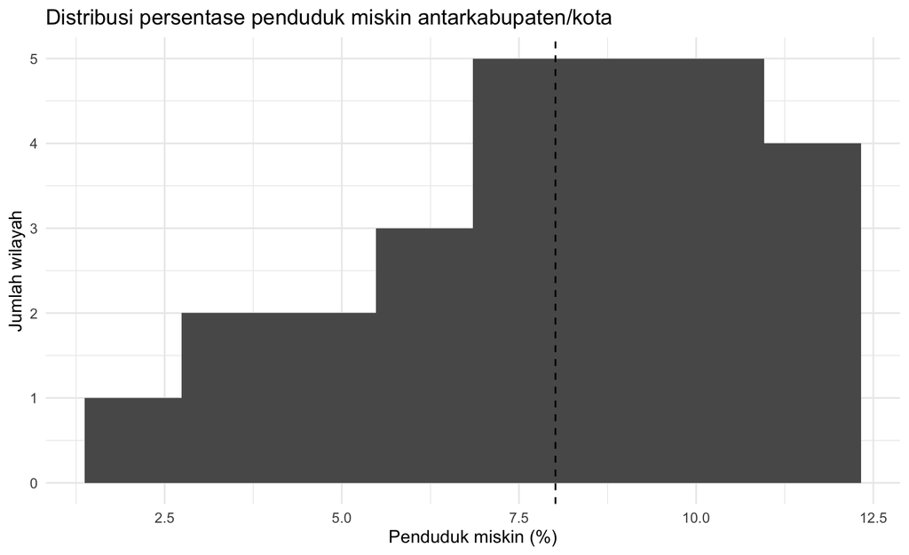

```r
ggplot2::ggplot(sf::st_drop_geometry(jabar13), ggplot2::aes(kemiskinan_persen_2024)) +
  ggplot2::geom_histogram(bins = 8, boundary = 0) +
  ggplot2::geom_vline(xintercept = mean(jabar13$kemiskinan_persen_2024), linetype = 2) +
  ggplot2::labs(title = "Distribusi persentase penduduk miskin antarkabupaten/kota", x = "Penduduk miskin (%)", y = "Jumlah wilayah")
```

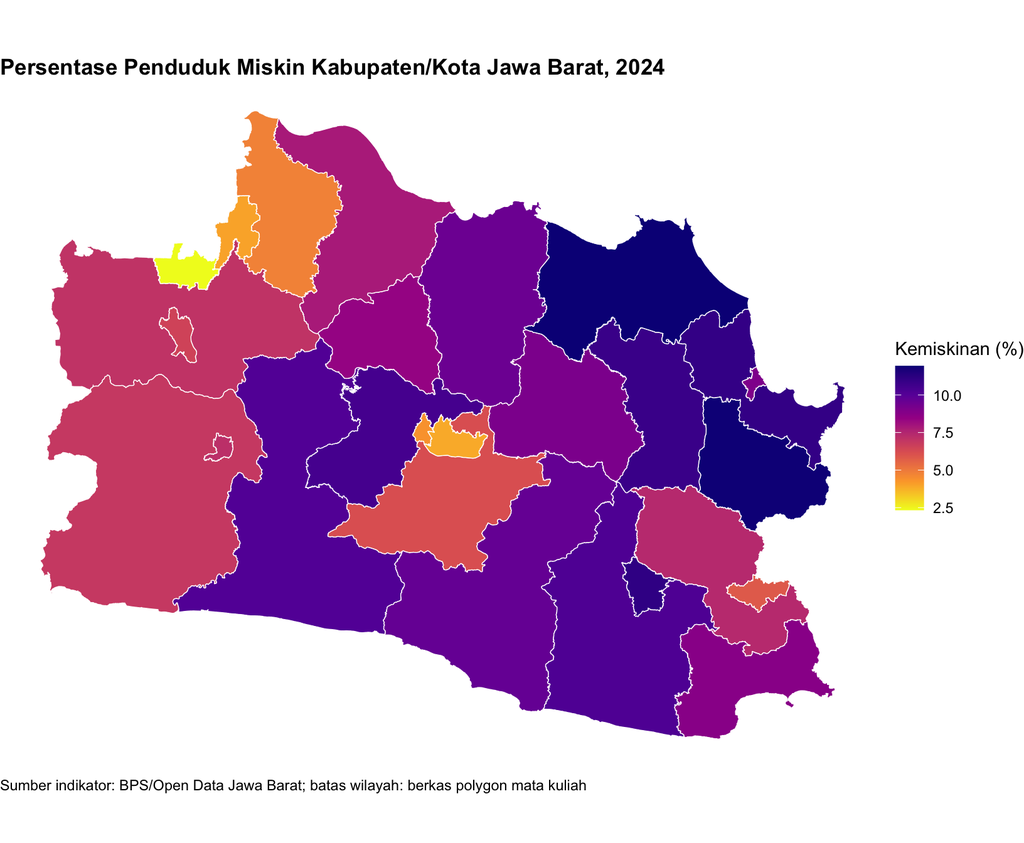

```r
ggplot2::ggplot(jabar13) +
  ggplot2::geom_sf(ggplot2::aes(fill = kemiskinan_persen_2024), colour = "white", linewidth = .25) +
  ggplot2::scale_fill_viridis_c(option = "C", direction = -1) +
  ggplot2::labs(title = "Persentase Penduduk Miskin Kabupaten/Kota Jawa Barat, 2024", fill = "Kemiskinan (%)", caption = "Sumber indikator: BPS/Open Data Jawa Barat; batas wilayah: berkas polygon mata kuliah") +
  ggplot2::theme_void() +
  ggplot2::theme(plot.title = ggplot2::element_text(face = "bold"), plot.caption = ggplot2::element_text(hjust = 0))
```

Choropleth menampilkan **rate**, bukan jumlah absolut. Ini penting karena polygon luas atau berpenduduk besar tidak otomatis memiliki tingkat kemiskinan tinggi.

## 13.10 Struktur Ketetanggaan Antar-Polygon

```r
# Bobot utama: polygon saling beririsan/bersinggungan (intersection adjacency).
rel_inter13 <- sf::st_intersects(jabar13)
n13 <- nrow(jabar13)
W_inter13 <- matrix(0, n13, n13)
for (i in seq_len(n13)) {
  jj <- setdiff(rel_inter13[[i]], i)
  if (length(jj) > 0) W_inter13[i, jj] <- 1
}

# Bobot alternatif: jarak minimum antar-polygon <= 10 km.
jabar13_m <- sf::st_transform(jabar13, 32748)
D13 <- units::drop_units(sf::st_distance(jabar13_m))
diag(D13) <- Inf
W_10km13 <- 1L * (D13 <= 10000)
diag(W_10km13) <- 0L

neighbor_tbl13 <- tibble::tibble(
  nama_kabupaten_kota = jabar13$nama_kabupaten_kota,
  intersection_neighbors = rowSums(W_inter13),
  neighbors_within_10km = rowSums(W_10km13)
)
knitr::kable(neighbor_tbl13, caption = "Jumlah tetangga areal: intersection dan proximity 10 km")
```

Table 13.5: Jumlah tetangga areal: intersection dan proximity 10 km

| nama_kabupaten_kota | intersection_neighbors | neighbors_within_10km |
| --- | --- | --- |
| KABUPATEN BOGOR | 8 | 8 |
| KABUPATEN SUKABUMI | 3 | 4 |
| KABUPATEN CIANJUR | 6 | 8 |
| KABUPATEN BANDUNG | 7 | 7 |
| KABUPATEN GARUT | 4 | 6 |
| KABUPATEN TASIKMALAYA | 6 | 7 |
| KABUPATEN CIAMIS | 6 | 8 |
| KABUPATEN KUNINGAN | 3 | 4 |
| KABUPATEN CIREBON | 4 | 4 |
| KABUPATEN MAJALENGKA | 6 | 7 |
| KABUPATEN SUMEDANG | 6 | 9 |
| KABUPATEN INDRAMAYU | 4 | 4 |
| KABUPATEN SUBANG | 6 | 8 |
| KABUPATEN PURWAKARTA | 5 | 8 |
| KABUPATEN KARAWANG | 4 | 5 |
| KABUPATEN BEKASI | 3 | 5 |
| KABUPATEN BANDUNG BARAT | 6 | 7 |
| KABUPATEN PANGANDARAN | 2 | 3 |
| KOTA BOGOR | 1 | 3 |
| KOTA SUKABUMI | 1 | 2 |
| KOTA BANDUNG | 3 | 6 |
| KOTA CIREBON | 1 | 2 |
| KOTA BEKASI | 3 | 3 |
| KOTA DEPOK | 2 | 4 |
| KOTA CIMAHI | 3 | 5 |
| KOTA TASIKMALAYA | 2 | 2 |
| KOTA BANJAR | 1 | 3 |

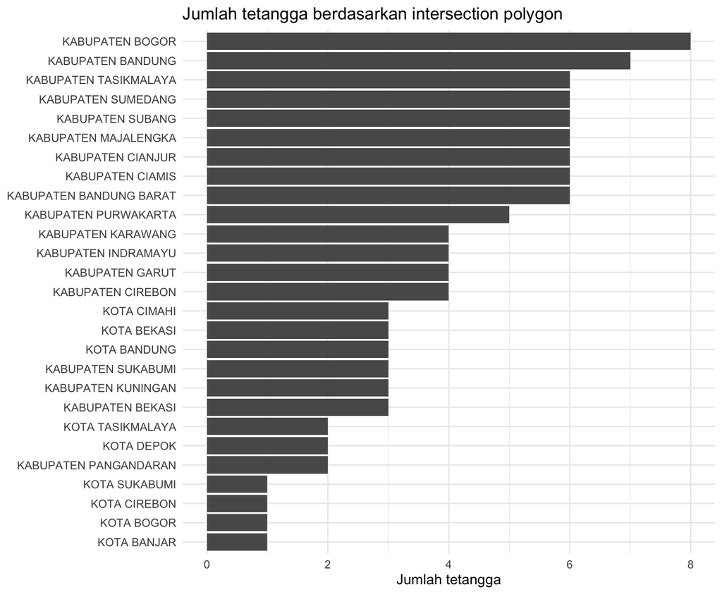

```r
ggplot2::ggplot(neighbor_tbl13, ggplot2::aes(reorder(nama_kabupaten_kota, intersection_neighbors), intersection_neighbors)) +
  ggplot2::geom_col() +
  ggplot2::coord_flip() +
  ggplot2::labs(title = "Jumlah tetangga berdasarkan intersection polygon", x = NULL, y = "Jumlah tetangga")
```

Perbedaan degree menunjukkan bahwa setiap wilayah memiliki jumlah tetangga berbeda. Row-standardization mencegah wilayah dengan banyak tetangga secara otomatis memiliki spatial lag yang lebih besar hanya karena jumlah koneksi.

## 13.11 Moran’s I Global dan Permutation Test

```r
lw_inter13 <- spdep::mat2listw(W_inter13, style = "W", zero.policy = TRUE)
y13 <- jabar13$kemiskinan_persen_2024

moran_test13 <- spdep::moran.test(y13, lw_inter13, zero.policy = TRUE, randomisation = TRUE)
set.seed(260813)
moran_mc13 <- spdep::moran.mc(y13, lw_inter13, nsim = 999, zero.policy = TRUE)

moran_out13 <- tibble::tibble(
  statistic = "Moran's I — polygon intersection",
  I_observed = unname(moran_test13$estimate[[1]]),
  expectation = unname(moran_test13$estimate[[2]]),
  variance = unname(moran_test13$estimate[[3]]),
  p_asymptotic = moran_test13$p.value,
  p_permutation = moran_mc13$p.value
)
knitr::kable(moran_out13, digits = 4, caption = "Autocorrelation global kemiskinan Jawa Barat")
```

Table 13.6: Autocorrelation global kemiskinan Jawa Barat

| statistic | I_observed | expectation | variance | p_asymptotic | p_permutation |
| --- | --- | --- | --- | --- | --- |
| Moran’s I — polygon intersection | 0.4776 | -0.0385 | 0.0199 | 0.0001 | 0.001 |

P-value permutation lebih sesuai untuk pembelajaran karena secara eksplisit membandingkan pola observasi dengan distribusi acak hasil pengacakan label wilayah.

## 13.12 Moran Scatterplot

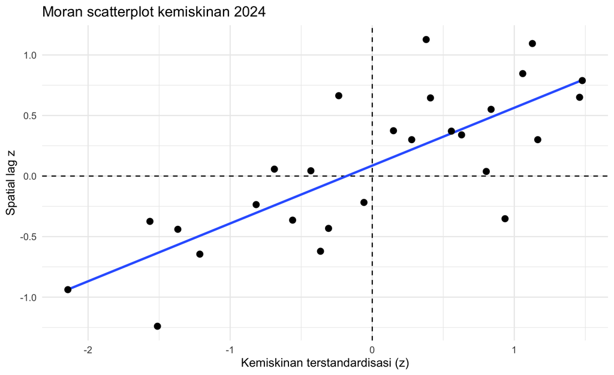

```r
z13 <- as.numeric(scale(y13))
lag_z13 <- spdep::lag.listw(lw_inter13, z13, zero.policy = TRUE)
scatter13 <- tibble::tibble(
  wilayah = jabar13$nama_kabupaten_kota,
  z = z13,
  spatial_lag_z = lag_z13
)

ggplot2::ggplot(scatter13, ggplot2::aes(z, spatial_lag_z)) +
  ggplot2::geom_hline(yintercept = 0, linetype = 2) +
  ggplot2::geom_vline(xintercept = 0, linetype = 2) +
  ggplot2::geom_smooth(method = "lm", se = FALSE) +
  ggplot2::geom_point(size = 2.6) +
  ggplot2::labs(title = "Moran scatterplot kemiskinan 2024", x = "Kemiskinan terstandardisasi (z)", y = "Spatial lag z")
```

Kuadran kanan-atas dan kiri-bawah merepresentasikan kemiripan lokal (high–high dan low–low), sedangkan dua kuadran lainnya menandai kontras lokal.

## 13.13 Local Moran dan Peta LISA

```r
local13 <- spdep::localmoran(y13, lw_inter13, zero.policy = TRUE)

jabar13$Ii <- local13[, "Ii"]
jabar13$Z_Ii <- local13[, "Z.Ii"]
pcol13 <- grep("^Pr", colnames(local13), value = TRUE)[1]
jabar13$p_local <- local13[, pcol13]
jabar13$z <- z13
jabar13$lag_z <- lag_z13
jabar13$quadrant <- dplyr::case_when(
  jabar13$z >= 0 & jabar13$lag_z >= 0 ~ "High–High",
  jabar13$z < 0 & jabar13$lag_z < 0 ~ "Low–Low",
  jabar13$z >= 0 & jabar13$lag_z < 0 ~ "High–Low",
  TRUE ~ "Low–High"
)
jabar13$lisa_class <- ifelse(jabar13$p_local <= .05, jabar13$quadrant, "Tidak signifikan")

local_tbl13 <- jabar13 |>
  sf::st_drop_geometry() |>
  dplyr::select(nama_kabupaten_kota, kemiskinan_persen_2024, Ii, Z_Ii, p_local, lisa_class) |>
  dplyr::arrange(p_local)
knitr::kable(local_tbl13, digits = 4, caption = "Local Moran dan klasifikasi LISA")
```

Table 13.7: Local Moran dan klasifikasi LISA

| nama_kabupaten_kota | kemiskinan_persen_2024 | Ii | Z_Ii | p_local | lisa_class |
| --- | --- | --- | --- | --- | --- |
| KABUPATEN CIREBON | 11.00 | 1.2809 | 2.4893 | 0.0128 | High–High |
| KABUPATEN MAJALENGKA | 10.82 | 0.9306 | 2.4846 | 0.0130 | High–High |
| KOTA BEKASI | 4.01 | 1.9470 | 2.4593 | 0.0139 | Low–Low |
| KABUPATEN BOGOR | 7.05 | 0.2348 | 2.1219 | 0.0338 | Low–Low |
| KABUPATEN INDRAMAYU | 11.93 | 1.2103 | 1.8862 | 0.0593 | Tidak signifikan |
| KABUPATEN SUMEDANG | 9.10 | 0.2746 | 1.8163 | 0.0693 | Tidak signifikan |
| KABUPATEN CIAMIS | 7.39 | -0.1624 | -1.7941 | 0.0728 | Tidak signifikan |
| KOTA DEPOK | 2.34 | 2.0870 | 1.6298 | 0.1031 | Tidak signifikan |
| KABUPATEN TASIKMALAYA | 10.23 | 0.4785 | 1.6194 | 0.1054 | Tidak signifikan |
| KABUPATEN KUNINGAN | 11.88 | 0.9855 | 1.3336 | 0.1823 | Tidak signifikan |
| KABUPATEN BEKASI | 4.80 | 0.8127 | 1.2871 | 0.1981 | Tidak signifikan |
| KOTA CIREBON | 9.02 | 0.4444 | 1.1451 | 0.2522 | Tidak signifikan |
| KABUPATEN SUBANG | 9.49 | 0.2146 | 1.0810 | 0.2797 | Tidak signifikan |
| KABUPATEN PURWAKARTA | 8.41 | 0.0581 | 0.9278 | 0.3535 | Tidak signifikan |
| KOTA CIMAHI | 4.39 | 0.6248 | 0.9242 | 0.3554 | Tidak signifikan |
| KABUPATEN BANDUNG BARAT | 10.49 | -0.3418 | -0.8816 | 0.3780 | Tidak signifikan |
| KOTA BANDUNG | 3.87 | 0.6081 | 0.8258 | 0.4089 | Tidak signifikan |
| KABUPATEN GARUT | 9.68 | 0.2220 | 0.7827 | 0.4338 | Tidak signifikan |
| KOTA TASIKMALAYA | 11.10 | 0.3634 | 0.5123 | 0.6084 | Tidak signifikan |
| KABUPATEN KARAWANG | 7.86 | 0.0132 | 0.4692 | 0.6389 | Tidak signifikan |
| KABUPATEN PANGANDARAN | 8.75 | 0.0866 | 0.4497 | 0.6530 | Tidak signifikan |
| KOTA SUKABUMI | 7.20 | 0.1380 | 0.4448 | 0.6565 | Tidak signifikan |
| KOTA BOGOR | 6.53 | 0.2119 | 0.3881 | 0.6979 | Tidak signifikan |
| KOTA BANJAR | 5.85 | 0.2001 | 0.2708 | 0.7865 | Tidak signifikan |
| KABUPATEN CIANJUR | 10.14 | 0.0316 | 0.1910 | 0.8485 | Tidak signifikan |
| KABUPATEN BANDUNG | 6.19 | -0.0409 | -0.0938 | 0.9253 | Tidak signifikan |
| KABUPATEN SUKABUMI | 6.87 | -0.0196 | -0.0490 | 0.9610 | Tidak signifikan |

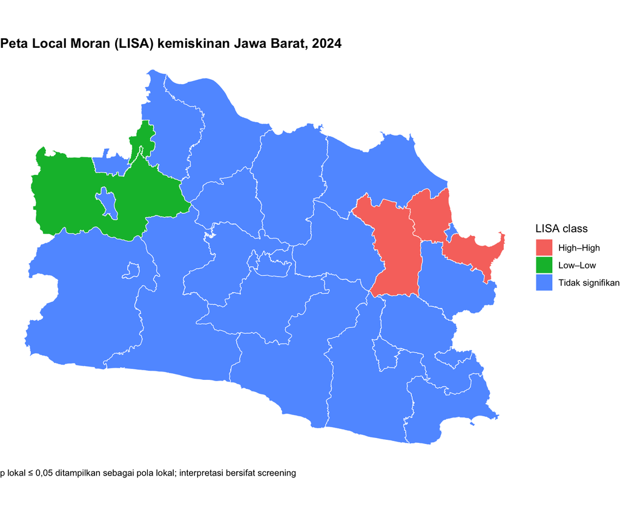

```r
ggplot2::ggplot(jabar13) +
  ggplot2::geom_sf(ggplot2::aes(fill = lisa_class), colour = "white", linewidth = .25) +
  ggplot2::labs(title = "Peta Local Moran (LISA) kemiskinan Jawa Barat, 2024", fill = "LISA class", caption = "p lokal ≤ 0,05 ditampilkan sebagai pola lokal; interpretasi bersifat screening") +
  ggplot2::theme_void() +
  ggplot2::theme(plot.title = ggplot2::element_text(face = "bold"), plot.caption = ggplot2::element_text(hjust = 0))
```

## 13.14 Sensitivity Analysis: Intersection versus Proximity 10 km

```r
lw_10km13 <- spdep::mat2listw(W_10km13, style = "W", zero.policy = TRUE)
set.seed(260813)
mc_inter13 <- spdep::moran.mc(y13, lw_inter13, nsim = 999, zero.policy = TRUE)
set.seed(260813)
mc_10km13 <- spdep::moran.mc(y13, lw_10km13, nsim = 999, zero.policy = TRUE)

sens13 <- tibble::tibble(
  neighborhood = c("Polygon intersection", "Polygon distance <= 10 km"),
  Moran_I = c(unname(mc_inter13$statistic), unname(mc_10km13$statistic)),
  p_permutation = c(mc_inter13$p.value, mc_10km13$p.value),
  mean_neighbors = c(mean(rowSums(W_inter13)), mean(rowSums(W_10km13)))
)
knitr::kable(sens13, digits = 4, caption = "Sensitivity Moran's I terhadap definisi neighborhood areal")
```

Table 13.8: Sensitivity Moran’s I terhadap definisi neighborhood areal

| neighborhood | Moran_I | p_permutation | mean_neighbors |
| --- | --- | --- | --- |
| Polygon intersection | 0.4776 | 0.001 | 3.9259 |
| Polygon distance <= 10 km | 0.4060 | 0.001 | 5.2593 |

Jika tanda, magnitude, atau kesimpulan inferensial berubah drastis antara intersection adjacency dan proximity 10 km, hasil harus dilaporkan sebagai sensitif terhadap definisi konektivitas. Neighborhood seharusnya mewakili mekanisme regional yang masuk akal; adjacency administratif belum tentu cocok untuk mobilitas komuter, perdagangan, DAS, atau jaringan transportasi.

## 13.15 Peta Interaktif Polygon

```r
pal13 <- leaflet::colorNumeric("YlOrRd", domain = jabar13$kemiskinan_persen_2024)
leaflet::leaflet(jabar13) |>
  leaflet::addProviderTiles("CartoDB.Positron") |>
  leaflet::addPolygons(
    fillColor = ~pal13(kemiskinan_persen_2024),
    fillOpacity = .75,
    weight = .8,
    color = "white",
    popup = ~paste0(
      "<b>", nama_kabupaten_kota, "</b><br>",
      "Kemiskinan 2024: ", round(kemiskinan_persen_2024, 2), "%<br>",
      "LISA: ", lisa_class
    )
  ) |>
  leaflet::addLegend(pal = pal13, values = ~kemiskinan_persen_2024, title = "Kemiskinan (%)")
```

[interactive chart not shown]

## 13.16 Interpretasi dalam Konteks Regional

Analisis areal mengubah pertanyaan dari “kabupaten mana paling tinggi?” menjadi “apakah kabupaten dengan kemiskinan tinggi berada dalam **lingkungan regional** yang juga memiliki nilai tinggi?”. Jika terdapat pola High–High, intervensi lintas batas dapat dipertimbangkan karena akses pekerjaan, transportasi, pasar, dan layanan publik tidak berhenti di garis administrasi. Sebaliknya, High–Low dapat menunjukkan wilayah yang berbeda tajam dari tetangganya dan layak ditelaah sebagai kasus khusus.

Namun spatial autocorrelation **tidak menjelaskan penyebab**. Pola dapat muncul karena struktur ekonomi yang mirip, topografi, aksesibilitas, urbanisasi, kebijakan historis, atau proses pengukuran. Untuk membuat klaim mekanisme diperlukan variabel tambahan dan model yang sesuai.

## 13.17 MAUP dan Ecological Fallacy

**Modifiable Areal Unit Problem (MAUP)** berarti hasil statistik dapat berubah bila batas atau tingkat agregasi wilayah diubah. Kabupaten/kota adalah satu pilihan agregasi administratif, bukan satu-satunya representasi proses sosial-ekonomi.

**Ecological fallacy** terjadi jika hubungan pada tingkat kabupaten langsung diterapkan kepada individu. Misalnya, kabupaten dengan kemiskinan tinggi tidak berarti setiap rumah tangga di kabupaten itu miskin, dan asosiasi antara internet dan kemiskinan antarkabupaten tidak sama dengan hubungan pada rumah tangga. (Pebesma dan Bivand 2023; Lovelace, Nowosad, dan Muenchow 2025)

## 13.18 Latihan

1. Jelaskan perbedaan contiguity klasik, intersection adjacency, dan proximity antar-polygon.
2. Mengapa polygon lebih tepat daripada titik centroid untuk outcome kabupaten/kota?
3. Apa arti Moran’s $I$ positif tetapi permutation p-value besar?
4. Bandingkan choropleth menggunakan *quantile breaks* dan *continuous scale*. Apakah persepsi disparitas berubah?
5. Identifikasi wilayah dengan silhouette—bukan, pada bab ini **LISA**—High–High dan Low–Low. Apa data tambahan yang perlu diperiksa sebelum rekomendasi dibuat?
6. Jelaskan satu contoh MAUP dan satu contoh ecological fallacy dalam analisis kemiskinan regional.

### 13.18.1 Tugas Terstruktur Pertemuan 13

Gunakan polygon Jawa Barat dan outcome regional dari BPS/Open Data Jabar. Tampilkan **audit geometry, audit join, statistik deskriptif, ranking, choropleth, degree neighborhood, Moran’s I + permutation test, Moran scatterplot, Local Moran/LISA map, dan sensitivity intersection vs proximity polygon**. Akhiri dengan memo 300–400 kata yang memisahkan temuan deskriptif, temuan spasial, hipotesis mekanisme, dan rekomendasi data lanjutan.

### 13.18.2 Kuis Formatif Pertemuan 13

1. Tuliskan rumus Moran’s $I$ dan jelaskan $S_0$.
2. Apa tujuan row-standardization pada $W$?
3. Apa beda High–High dengan High–Low?
4. Mengapa local p-values memerlukan kehati-hatian karena multiple testing?
5. Mengapa autocorrelation spasial tidak sama dengan causal spillover?

## 13.19 Hubungan dengan Capstone Project

Jika capstone menggunakan unit wilayah, tim harus memutuskan apakah geografi hanya untuk visualisasi atau merupakan bagian dari mekanisme analitik. Bila struktur spasial relevan, minimal lakukan audit neighborhood dan satu sensitivity analysis. Peta tidak boleh menjadi dekorasi; ia harus menjawab pertanyaan substantif.

## 13.20 Kesimpulan

Regional data science membutuhkan *areal thinking*. Untuk indikator kabupaten/kota, polygon, neighborhood, spatial lag, global Moran, dan Local Moran memberi kerangka yang lebih tepat daripada sekadar plot titik. Analisis tetap harus menjaga batas inferensi: pola spasial adalah evidence tentang struktur, bukan otomatis evidence tentang sebab.

## 13.21 Pendalaman Magister — Areal Spatial Reasoning

### 13.21.1 Audit metodologis

1. Apakah geometry dan outcome berada pada unit administratif yang sama?
2. Apakah CRS dan vintage boundary telah diverifikasi?
3. Apakah join menggunakan kode wilayah dan seluruh unmatched record diaudit?
4. Apakah definisi $W$ memiliki justifikasi substantif?
5. Apakah inference global menggunakan randomization/permutation check?
6. Apakah Local Moran dibaca sebagai screening dan bukan causal cluster?
7. Apakah MAUP serta ecological fallacy dinyatakan secara eksplisit?

### 13.21.2 Pertanyaan Viva

1. Mengapa data kabupaten/kota disebut areal data?
2. Apa yang berubah ketika definisi neighborhood diubah dari intersection menjadi proximity 10 km?
3. Bagaimana membaca Moran scatterplot?
4. Apa perbedaan global Moran dan Local Moran?
5. Kapan spatial autocorrelation seharusnya memengaruhi desain model prediktif?

# 14 Model Comparison, Uncertainty, Fairness, dan Evaluasi Kebijakan

## 14.1 Pendahuluan

Model terbaik bukan selalu model dengan metric agregat paling kecil. Keputusan regional membutuhkan evaluasi robustness, uncertainty, subgroup performance, fairness, dan konsekuensi operasional. Model card adalah salah satu cara mendokumentasikan intended use, metric, keterbatasan, dan kelompok kinerja. (Mitchell dkk. 2019)

## 14.2 Tujuan Pembelajaran

Mahasiswa mampu membandingkan model pada metric yang relevan, menganalisis residual/subgroup, melakukan sensitivity analysis sederhana, dan menyusun *model card*.

## 14.3 Definisi dan Konsep

**Robustness** adalah kestabilan kesimpulan terhadap perubahan data/model yang wajar. **Fairness** di konteks regional berarti memeriksa apakah error sistematis lebih besar pada kelompok wilayah tertentu. Hal ini bukan sekadar masalah teknis; definisi fairness terkait tujuan program.

## 14.4 Formulasi Matematis

Perbedaan error antargrup:

$$\Delta_{MAE}=MAE_A-MAE_B.$$

Coverage interval prediksi:

$$Coverage=\frac{1}{n}\sum_{i=1}^{n} I(L_i\le y_i\le U_i),$$

dengan $[L_i,U_i]$ interval prediksi. Coverage nominal 95% idealnya mendekati 0,95 pada data yang relevan.

### 14.4.1 Perbandingan model sebagai estimasi ketidakpastian

Jika $m_{bk}$ adalah nilai metrik model $k$ pada resample $b=1,\dots,B$, rata-rata dan standard error resampling:
$$\bar m_k=\frac{1}{B}\sum_{b=1}^{B}m_{bk},\qquad
SE(\bar m_k)=\frac{s_{m_k}}{\sqrt B}.$$
Selisih kecil dibanding variability resampling tidak layak diperlakukan sebagai bukti bahwa satu model “pasti terbaik”. Pertimbangkan kesederhanaan, interpretability, latency, fairness, dan data requirements. (Kuhn dan Silge 2022)

### 14.4.2 Bootstrap untuk uncertainty

Ambil $B$ bootstrap samples dan hitung statistic $\hat\theta^{*(b)}$. Bootstrap standard error:
$$\widehat{SE}_{boot}(\hat\theta)=\sqrt{\frac{1}{B-1}\sum_{b=1}^{B}(\hat\theta^{*(b)}-\bar\theta^{*})^2}.$$
Bootstrap dapat diterapkan pada koefisien, ranking, atau metrik model, dengan resampling scheme yang menghormati struktur panel/spasial jika diperlukan.

### 14.4.3 Ranking stability

Jika $r_i^{(a)}$ dan $r_i^{(b)}$ adalah ranking wilayah di dua skenario bobot/model, Spearman rank correlation:
$$\rho_s=1-\frac{6\sum_i d_i^2}{n(n^2-1)},\qquad d_i=r_i^{(a)}-r_i^{(b)}.$$
Jika daftar “10 wilayah prioritas” berubah drastis karena sedikit perubahan bobot, rekomendasi harus dilaporkan sebagai tidak stabil.

### 14.4.4 Fairness metrics

Untuk protected/context group $A$:

**Demographic parity difference**
$$DP=P(\hat Y=1\mid A=a)-P(\hat Y=1\mid A=b).$$

**Equal opportunity difference**
$$EO=P(\hat Y=1\mid Y=1,A=a)-P(\hat Y=1\mid Y=1,A=b).$$

Tidak ada satu fairness metric yang selalu tepat; kriteria dapat saling bertentangan dan konteks hukum/etik menentukan apa yang relevan. Dalam regional policy, group dapat berupa urban/rural, pulau/kawasan, atau kategori kapasitas fiskal—tetapi penggunaan kategori harus punya dasar substantif dan tidak menstigmatisasi. (Hardt, Price, dan Srebro 2016)

### 14.4.5 Calibration dan decision curve sederhana

Jika benefit intervensi dan cost berbeda, net benefit pada threshold $t$ dapat ditulis secara sederhana:
$$NB(t)=\frac{TP(t)}{n}-\frac{FP(t)}{n}\frac{t}{1-t}.$$
Rumus berasal dari decision-analytic framing tertentu dan tidak otomatis berlaku untuk semua kebijakan; gunakan sebagai contoh bahwa threshold harus dihubungkan dengan trade-off keputusan.

### 14.4.6 Dari prediction ke policy evaluation: Difference-in-Differences

Jika ada treated group $D=1$ dan control $D=0$, sebelum ($t=0$) dan sesudah ($t=1$), estimand DID:
$$\widehat\tau_{DID}=(\bar Y_{1,post}-\bar Y_{1,pre})-(\bar Y_{0,post}-\bar Y_{0,pre}).$$
Regresi:
$$Y_{it}=\alpha+\beta D_i+\gamma Post_t+\tau(D_i\times Post_t)+\varepsilon_{it}.$$
Interpretasi kausal membutuhkan asumsi **parallel trends** dan desain yang kredibel. DID dimasukkan untuk menunjukkan perbedaan antara “memprediksi outcome” dan “mengevaluasi apakah kebijakan menyebabkan perubahan”. (Callaway dan Sant’Anna 2021; Hernán dan Robins 2020)

## 14.5 Intuisi Metode

Model yang rata-rata bagus bisa buruk untuk daerah berpenduduk kecil atau data terbatas. Jika model digunakan untuk alokasi bantuan, error tidak merata dapat memperkuat ketimpangan.

### 14.5.1 Worked Example — model difference relative to uncertainty

Model A RMSE fold: 2.1,2.2,2.0,2.4,2.3 → mean 2.20. Model B: 2.05,2.18,1.98,2.36,2.28 → mean 2.17. Selisih 0.03 sangat kecil dibanding variasi antar-fold. Menyebut B “jauh lebih baik” tidak didukung. Pertimbangkan paired resample differences dan simplicity.

### 14.5.2 Bootstrap ranking

Untuk setiap bootstrap $b$, hitung score/ranking wilayah. Untuk wilayah $i$, laporkan median rank dan interval percentile:
$$CI_{rank,i}=[Q_{0.025}(r_i^*),Q_{0.975}(r_i^*)].$$
Jika wilayah ranking 8 memiliki interval 3–19, penetapan cut-off “top 10” harus hati-hati.

### 14.5.3 Fairness numeric

Group urban: TPR=0.90; rural: TPR=0.65. Equal opportunity difference urban–rural=0.25. Ini memberi sinyal model lebih sering melewatkan prioritas rural. Penyebab dapat berasal dari data quality, feature availability, label process, atau heterogeneity; fairness diagnostic bukan diagnosis penyebab.

### 14.5.4 DID numeric

Treated outcome: pre 60, post 75 → +15. Control: pre 58, post 65 → +7.
$$\widehat\tau_{DID}=15-7=8.$$
Interpretasi kausal memerlukan parallel trends dan tidak adanya perubahan berbeda lain yang confound treatment timing. Uji/plot pre-trends penting, dan modern DID perlu memperhatikan staggered adoption. (Callaway dan Sant’Anna 2021)

### 14.5.5 Robustness matrix

| Analytic choice | Base | Alternative | Result stable? |
| --- | --- | --- | --- |
| weights index | 0.5/0.3/0.2 | equal weights | yes/no |
| split | temporal | grouped region | yes/no |
| model | RF | ridge/logit | yes/no |
| W spatial | queen | kNN | yes/no |
| missing | complete case | imputation/sensitivity | yes/no |

Capstone harus menyimpulkan bukan hanya “hasil”, tetapi **set of results that survive reasonable alternatives**.

### 14.5.6 Uncertainty hierarchy

Bedakan: 1. sampling uncertainty; 2. measurement error; 3. model uncertainty; 4. hyperparameter uncertainty; 5. scenario/weight uncertainty; 6. structural uncertainty tentang mekanisme regional.

CI koefisien hanya menangkap sebagian dari daftar tersebut. Kebijakan berbasis data harus menghindari *false precision*.

## 14.6 Contoh dengan Data Simulasi

```r
panel <- read_csv("data/simulasi_panel_regional.csv", show_col_types = FALSE)
train <- panel |> filter(tahun <= 2023)
test <- panel |> filter(tahun >= 2024)
fit <- lm(kemiskinan_persen ~ pdrb_perkapita_juta + tpt_persen + internet_persen + ipm, data = train)
ev <- test |> mutate(pred = predict(fit, newdata = test), abs_err = abs(kemiskinan_persen-pred))

ev |>
  group_by(urban) |>
  summarise(n=n(), MAE=mean(abs_err), RMSE=sqrt(mean((kemiskinan_persen-pred)^2))) |>
  knitr::kable(digits=3, caption="Kinerja model menurut tipe wilayah - simulasi")
```

Table 14.1: Kinerja model menurut tipe wilayah - simulasi

| urban | n | MAE | RMSE |
| --- | --- | --- | --- |
| 0 | 22 | 1.343 | 1.611 |
| 1 | 32 | 0.927 | 1.259 |

### 14.6.1 Visualisasi Output: Error menurut Tipe Wilayah

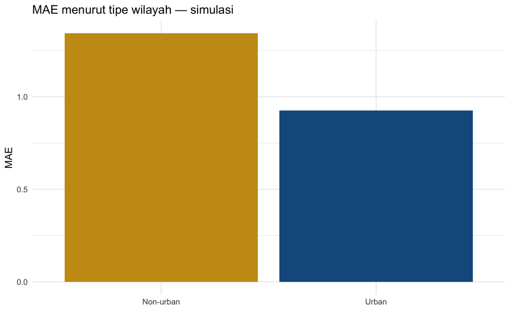

```r
ev |>
  dplyr::group_by(urban) |>
  dplyr::summarise(MAE = mean(abs_err), .groups = "drop") |>
  dplyr::mutate(tipe = ifelse(urban == 1, "Urban", "Non-urban")) |>
  ggplot2::ggplot(ggplot2::aes(tipe, MAE, fill = tipe)) +
  ggplot2::geom_col(show.legend = FALSE) +
  ggplot2::scale_fill_manual(values = c("Urban" = "#145B8C", "Non-urban" = "#C99A17")) +
  ggplot2::labs(title = "MAE menurut tipe wilayah — simulasi", x = NULL, y = "MAE")
```

## 14.7 Contoh dengan Data Nyata

Pada INDO-DAPOER atau Open Data Jabar, subgroup dapat dibentuk dari status kota/kabupaten, quantile populasi, zona geografis, atau kategori berbasis teori. Hindari menciptakan subgroup kecil yang membuat metric sangat tidak stabil.

**Kartu dataset real.**

- **Nama:** INDO-DAPOER atau Open Data Jawa Barat untuk audit subgroup dan robustness.
- **Sumber dan URL:** INDO-DAPOER https://datacatalog.worldbank.org/search/dataset/0041056/indonesia-database-for-policy-and-economic-research; Open Data Jabar https://opendata.jabarprov.go.id/.
- **Tahun:** sesuai analytic sample; semua subgroup harus berasal dari periode dan definisi yang kompatibel.
- **Unit observasi:** wilayah–tahun atau wilayah pada satu tahun.
- **Variabel/definisi:** outcome/prediction, residual/error, status kabupaten/kota atau subgroup berbasis ukuran/populasi/geografi; subgroup harus didefinisikan sebelum melihat hasil jika digunakan untuk evaluasi formal.
- **Alasan digunakan:** memperlihatkan bahwa average performance dapat menyembunyikan error tinggi pada jenis wilayah tertentu.
- **Keterbatasan:** subgroup kecil menghasilkan metric tidak stabil; fairness statistik tidak identik dengan keadilan kebijakan dan perlu interpretasi institusional. (World Bank 2026; Pemerintah Provinsi Jawa Barat 2026b)

## 14.8 Analisis Menggunakan R

```r
# Sensitivitas ranking prioritas terhadap bobot indikator.
latest <- panel |> filter(tahun == 2025)
rank_a <- latest |>
  mutate(score = .6*as.numeric(scale(kemiskinan_persen)) + .4*as.numeric(scale(tpt_persen))) |>
  arrange(desc(score)) |>
  mutate(rank_a = row_number())
rank_b <- latest |>
  mutate(score = .4*as.numeric(scale(kemiskinan_persen)) + .3*as.numeric(scale(tpt_persen)) - .3*as.numeric(scale(ipm))) |>
  arrange(desc(score)) |>
  mutate(rank_b = row_number())
left_join(rank_a |> select(wilayah, rank_a), rank_b |> select(wilayah, rank_b), by="wilayah") |>
  mutate(delta_rank = rank_b-rank_a) |>
  arrange(desc(abs(delta_rank))) |>
  head(10) |>
  knitr::kable()
```

| wilayah | rank_a | rank_b | delta_rank |
| --- | --- | --- | --- |
| Wilayah_21 | 15 | 3 | -12 |
| Wilayah_14 | 11 | 22 | 11 |
| Wilayah_27 | 17 | 9 | -8 |
| Wilayah_26 | 5 | 11 | 6 |
| Wilayah_25 | 13 | 19 | 6 |
| Wilayah_24 | 8 | 13 | 5 |
| Wilayah_07 | 1 | 5 | 4 |
| Wilayah_01 | 19 | 15 | -4 |
| Wilayah_10 | 21 | 25 | 4 |
| Wilayah_08 | 24 | 20 | -4 |

## 14.9 Paket Output Evaluasi Model Lengkap

```r
d14 <- readr::read_csv("data/simulasi_panel_regional.csv", show_col_types=FALSE) |>
  dplyr::filter(tahun==2025)
set.seed(260814)
s14 <- rsample::initial_split(d14, prop=.8)
tr14 <- rsample::training(s14); te14 <- rsample::testing(s14)

lm14 <- stats::lm(kemiskinan_persen ~ pdrb_perkapita_juta+tpt_persen+ipm+internet_persen+umkm_per_1000, data=tr14)
rf14 <- ranger::ranger(kemiskinan_persen ~ pdrb_perkapita_juta+tpt_persen+ipm+internet_persen+umkm_per_1000, data=tr14, num.trees=500, seed=260814)

pred14 <- dplyr::bind_rows(
  tibble::tibble(actual=te14$kemiskinan_persen, pred=predict(lm14,newdata=te14), model="Linear"),
  tibble::tibble(actual=te14$kemiskinan_persen, pred=predict(rf14,data=te14)$predictions, model="Random forest")
) |> dplyr::mutate(error=pred-actual)

metric14 <- pred14 |> dplyr::group_by(model) |>
  dplyr::summarise(RMSE=sqrt(mean(error^2)), MAE=mean(abs(error)), Bias=mean(error), P90_AbsError=quantile(abs(error),.90), .groups="drop")
knitr::kable(metric14, digits=3, caption="Perbandingan metric utama dan tail error")
```

Table 14.2: Perbandingan metric utama dan tail error

| model | RMSE | MAE | Bias | P90_AbsError |
| --- | --- | --- | --- | --- |
| Linear | 1.171 | 1.032 | -0.993 | 1.626 |
| Random forest | 0.954 | 0.821 | -0.800 | 1.349 |

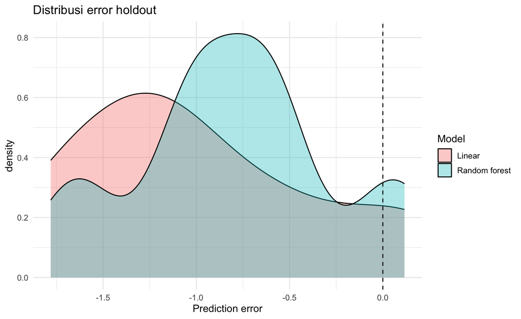

```r
ggplot2::ggplot(pred14, ggplot2::aes(error, fill=model)) +
  ggplot2::geom_density(alpha=.35) + ggplot2::geom_vline(xintercept=0,linetype=2) +
  ggplot2::labs(title="Distribusi error holdout", x="Prediction error", fill="Model")
```

```r
worst14 <- pred14 |> dplyr::group_by(model) |> dplyr::slice_max(abs(error), n=5, with_ties=FALSE) |> dplyr::ungroup()
knitr::kable(worst14, digits=3, caption="Lima error absolut terbesar per model")
```

Table 14.3: Lima error absolut terbesar per model

| actual | pred | model | error |
| --- | --- | --- | --- |
| 11.637 | 9.856 | Linear | -1.781 |
| 10.966 | 9.495 | Linear | -1.471 |
| 10.098 | 8.929 | Linear | -1.169 |
| 11.810 | 10.715 | Linear | -1.095 |
| 9.444 | 8.887 | Linear | -0.557 |
| 11.637 | 9.994 | Random forest | -1.643 |
| 10.966 | 9.911 | Random forest | -1.055 |
| 9.444 | 8.495 | Random forest | -0.949 |
| 11.810 | 11.166 | Random forest | -0.644 |
| 10.098 | 9.528 | Random forest | -0.570 |

## 14.10 Interpretasi dalam Konteks Regional

Jika prioritas berubah drastis hanya karena bobot sedikit berubah, sistem ranking rapuh. Kebijakan sebaiknya menampilkan tier atau range, bukan ranking presisi 1-27 yang memberi kesan kepastian palsu.

## 14.11 Latihan

1. Apa beda robustness dan accuracy?
2. Mengapa subgroup evaluation penting untuk kebijakan regional?
3. Apa isi minimum model card?
4. **Analisis:** hitung MAE per kuartil kemiskinan.
5. **Analisis:** lakukan sensitivity ranking dengan tiga skema bobot.
6. **Mini-case:** model sedikit lebih akurat tetapi error meningkat besar di wilayah tertinggal. Putuskan apakah model dipakai dan jelaskan governance-nya.

### 14.11.1 Tugas Terstruktur Pertemuan 14

Lakukan **robustness audit** capstone: minimal dua skenario bobot/fitur, satu alternatif resampling/model, satu fairness slice, dan satu uncertainty summary. Buat tabel “temuan yang stabil” vs “temuan yang sensitif”.

### 14.11.2 Kuis 4 — Minggu 11–14 (2,5%)

Kisi-kisi: k-means objective; silhouette; PCA; Moran’s I; spatial weights; bootstrap SE; rank stability; fairness metric; calibration; prediction vs policy evaluation; DID intuition.

## 14.12 Hubungan dengan Capstone Project

Milestone evaluasi: tim menyertakan tabel comparison, subgroup check, sensitivity analysis, dan *model card* 1 halaman.

## 14.13 Kesimpulan

Evaluasi model adalah evaluasi risiko keputusan. Metric agregat harus dilengkapi robustness, subgroup performance, uncertainty, dan keterbatasan penggunaan.

## 14.14 Pendalaman Magister — Robustness, fairness, dan policy evaluation

### 14.14.1 Audit metodologis

1. Model winner ditentukan dari selisih trivial.
2. Ranking uncertainty tidak dilaporkan.
3. Fairness metric dipilih tanpa konteks.
4. Subgroup kecil dinilai terlalu pasti.
5. Did dipakai tanpa parallel trends.
6. Prediction disamakan dengan evaluation.

### 14.14.2 Pertanyaan viva / diskusi kelas

1. Apa practical significance selisih metric?
2. Bagaimana bootstrap membantu ranking?
3. Apa konflik fairness criteria?
4. Mengapa stability penting sebelum top-k policy?
5. Apa estimand DID?
6. Bagaimana membedakan model uncertainty dan policy uncertainty?

# 15 Data Science for Regional Policy, Dashboard, dan Generative AI yang Bertanggung Jawab

## 15.1 Pendahuluan

Tahap akhir analisis adalah mengubah bukti menjadi opsi kebijakan. Rekomendasi yang baik menunjukkan *evidence chain*: masalah → data → hasil → ketidakpastian → opsi → konsekuensi. Generative AI dapat mempercepat coding dan dokumentasi, tetapi juga dapat menghasilkan kode salah, referensi fiktif, atau interpretasi terlalu percaya diri. (Miao dan Holmes 2023; Tabassi 2023)

## 15.2 Tujuan Pembelajaran

Mahasiswa mampu menyusun policy insight, membedakan temuan dan rekomendasi, membuat dashboard ringkas, menggunakan GenAI secara transparan, dan mendokumentasikan verifikasi.

## 15.3 Definisi dan Konsep

**Evidence-based policy** bukan berarti keputusan dibuat oleh model. Bukti adalah input bersama nilai publik, hukum, anggaran, political feasibility, local knowledge, dan equity. AI berperan sebagai *assistant*, bukan otoritas epistemik.

Penggunaan GenAI yang diperbolehkan: menjelaskan dokumentasi package, menghasilkan skeleton kode, debugging, membuat alternatif visual, merapikan dokumentasi, dan brainstorming interpretasi awal. Kewajiban mahasiswa: memeriksa kode, memvalidasi output, membaca sumber asli, menguji asumsi, menghapus data sensitif, dan mendeklarasikan penggunaan AI.

## 15.4 Formulasi Matematis

Untuk keputusan berbasis expected loss, secara konseptual pilih tindakan $a$ yang meminimalkan

$$a^*=\arg\min_a E[L(a,\theta)\mid D],$$

di mana $L(a,\theta)$ adalah loss dari tindakan $a$ ketika keadaan sebenarnya $\theta$, dan $D$ adalah bukti/data. Formula ini menekankan bahwa keputusan bergantung pada **loss/konsekuensi**, bukan hanya prediksi.

### 15.4.1 Dari model output ke keputusan multi-kriteria

Jika kebijakan mempertimbangkan $p$ kriteria, score sederhana:
$$S_i=\sum_{j=1}^{p}w_j z_{ij},\qquad \sum_jw_j=1.$$
Tetapi jika model menghasilkan risk probability $\hat p_i$, score kebijakan dapat menggabungkan risiko dan feasibility:
$$Q_i=w_r\hat p_i+w_fF_i+w_eE_i,$$
dengan $F_i$ feasibility dan $E_i$ equity score. Persamaan ini **bukan resep universal**; tujuannya memperlihatkan bahwa transisi model→policy memerlukan pilihan eksplisit yang dapat diaudit.

### 15.4.2 Expected utility dan constrained prioritization

Jika intervensi $a_i\in\{0,1\}$, benefit ekspektasian $b_i$, biaya $c_i$, anggaran $B$:
$$\max_{a_i}\sum_i a_i b_i
\quad \text{s.t.}\quad \sum_i a_i c_i\le B.$$
Ini adalah bentuk knapsack/optimization sederhana. Model prediksi dapat membantu memperkirakan $b_i$ atau risiko, tetapi alokasi akhir tetap constrained decision problem.

### 15.4.3 Dashboard metrics dan denominator discipline

Jika dashboard menampilkan KPI, setiap KPI harus memiliki definisi matematis. Misalnya coverage:
$$Coverage=\frac{\text{beneficiaries reached}}{\text{target population}}\times100\%.$$

Change vs target:
$$Gap_t=x_t-T_t.$$

Percent target achievement (untuk target positif):
$$Achievement_t=\frac{x_t}{T_t}\times100\%.$$
Hindari persentase bila denominator nol/tidak stabil. Dashboard harus menampilkan sumber, periode, update time, dan status data.

### 15.4.4 Protokol validasi output Generative AI

Setiap keluaran AI yang memengaruhi analisis melewati empat lapis verifikasi:

$$V=V_{source}\times V_{code}\times V_{result}\times V_{interpretation},$$
di mana setiap $V_\cdot\in\{0,1\}$ pada checklist minimum. Jika salah satu nol, artefak belum layak dipakai. Ini bukan probabilistic score, tetapi *process-control device*.

- $V_{source}=1$: sumber/URL/metadata dicek langsung.
- $V_{code}=1$: kode dijalankan dan unit-tested secara minimal.
- $V_{result}=1$: hasil dibandingkan dengan sanity check/baseline.
- $V_{interpretation}=1$: klaim substantif diperiksa terhadap definisi data dan teori.

UNESCO menekankan pendekatan human-centred dan validasi etis-pedagogis untuk GenAI; NIST AI RMF mendorong governance, mapping, measurement, dan management risiko AI. (Miao dan Holmes 2023; Tabassi 2023; Autio dkk. 2024)

### 15.4.5 AI-use declaration minimum

Untuk setiap project, simpan tabel:

| Elemen | Isi minimum |
| --- | --- |
| Tool/model | nama layanan/model bila diketahui |
| Tanggal | kapan digunakan |
| Tujuan | dokumentasi, debugging, ide visualisasi, dsb. |
| Prompt category | ringkasan, bukan data sensitif mentah |
| Output used | bagian apa yang benar-benar digunakan |
| Verification | bagaimana kode/sumber/hasil diverifikasi |
| Human revision | perubahan substansial yang dilakukan mahasiswa |

Data personal, data rahasia, atau data dengan pembatasan lisensi tidak boleh ditempelkan ke layanan AI publik tanpa dasar dan izin yang sesuai.

### 15.4.6 Reproducibility sebagai kontrak ilmiah

Analisis yang reproducible dapat dipandang sebagai fungsi
$$Output=F(Data,Code,Parameters,Environment).$$
Jika salah satu komponen tidak tersedia atau berubah tanpa dokumentasi, output tidak dapat diaudit. Catat `sessionInfo()`, seed, package versions, sumber data, dan semua parameter preprocessing/model.

## 15.5 Intuisi Metode

Model dapat memberi probabilitas desa rentan 0,72. Kebijakan tetap harus menjawab: kapasitas verifikasi berapa, biaya salah sasaran berapa, data apa yang sensitif, siapa yang dapat mengajukan koreksi, dan kapan model ditinjau ulang.

### 15.5.1 Worked Example — constrained allocation

Empat wilayah memiliki expected benefit $(50,40,35,30)$ dan cost $(30,20,20,10)$ juta; budget 50. Memilih dua benefit terbesar A+B membutuhkan 50 dan benefit 90. Kombinasi A+D cost 40 benefit 80; B+C cost 40 benefit 75; B+C+D cost 50 benefit 105. Maka ranking benefit individual tidak cukup; constraint menghasilkan portfolio berbeda.

Ini memperjelas transisi dari risk prediction ke decision optimization. Model dapat menghasilkan risk/benefit estimate, tetapi resource allocation membutuhkan fungsi objective dan constraints.

### 15.5.2 Policy recommendation ladder

Gunakan lima tingkat klaim:

1. **Observed:** “TPT lebih tinggi di kelompok X pada data ini.”
2. **Associated:** “TPT berasosiasi dengan Y setelah conditioning model.”
3. **Predicted:** “Model memprediksi risiko tinggi pada wilayah Z.”
4. **Causal:** “Intervensi A menyebabkan perubahan B”—butuh design causal.
5. **Recommended:** “Lakukan A”—butuh evidence + feasibility + value judgment.

Jangan melompat dari tingkat 1–3 langsung ke 5 tanpa penjelasan tambahan.

### 15.5.3 Dashboard minimum viable architecture

Dashboard kebijakan sebaiknya memiliki empat layer: **overview → comparison → drill-down → methodology**. Overview menampilkan 3–5 KPI; comparison memungkinkan lintas wilayah/waktu; drill-down menampilkan profile; methodology menjelaskan source, formula, update, dan limitation.

### 15.5.4 Data freshness

Jika data terakhir tahun $t_d$ dan dashboard dibuka tahun $t_c$, lag:
$$Lag=t_c-t_d.$$
KPI dengan lag besar harus diberi badge “historical”/“latest available”, bukan ditampilkan seolah real-time. INDO-DAPOER berhenti 2018 sehingga cocok untuk latihan historis dan bukan kondisi terkini. (World Bank 2026)

### 15.5.5 AI verification example

AI menyarankan `scale()` sebelum split. Mahasiswa harus mengoreksi karena leakage. AI mengutip dataset “BPS Innovation Index 2025” yang tidak ditemukan: source verification gagal. AI menulis interpretasi “internet menurunkan kemiskinan”: interpretation verification gagal karena model hanya asosiasional. Contoh ini menunjukkan kode yang *syntactically plausible* tetap dapat salah secara ilmiah.

### 15.5.6 R log untuk AI use

```r
ai_log <- tibble::tribble(
 ~tanggal, ~tool, ~tujuan, ~output_used, ~verification,
 "2026-09-15", "Generative AI", "debug join", "saran anti_join", "dicek pada toy data dan dokumentasi dplyr",
 "2026-10-01", "Generative AI", "draft caption", "struktur caption", "angka dan klaim diverifikasi dari output sendiri"
)
knitr::kable(ai_log, caption="Contoh AI-use log")
```

Table 15.1: Contoh AI-use log

| tanggal | tool | tujuan | output_used | verification |
| --- | --- | --- | --- | --- |
| 2026-09-15 | Generative AI | debug join | saran anti_join | dicek pada toy data dan dokumentasi dplyr |
| 2026-10-01 | Generative AI | draft caption | struktur caption | angka dan klaim diverifikasi dari output sendiri |

### 15.5.7 Policy memo quality test

Setiap recommendation harus bisa ditelusuri ke evidence. Gunakan format: **Temuan → interpretasi → opsi → rekomendasi → indikator monitoring → caveat.** Jika satu rekomendasi tidak memiliki evidence chain, hapus atau ubah menjadi hipotesis untuk penelitian berikutnya.

## 15.6 Contoh dengan Data Simulasi

```r
latest <- read_csv("data/simulasi_panel_regional.csv", show_col_types = FALSE) |>
  filter(tahun == 2025) |>
  mutate(
    prioritas = case_when(
      kemiskinan_persen >= quantile(kemiskinan_persen,.75) & internet_persen < median(internet_persen) ~ "Inklusi digital + perlindungan sosial",
      tpt_persen >= quantile(tpt_persen,.75) & pdrb_perkapita_juta > median(pdrb_perkapita_juta) ~ "Matching tenaga kerja-industri",
      TRUE ~ "Monitoring / intervensi sektoral"
    )
  )
latest |> count(prioritas) |> knitr::kable(caption="Contoh penerjemahan pola menjadi opsi intervensi - simulasi")
```

Table 15.2: Contoh penerjemahan pola menjadi opsi intervensi - simulasi

| prioritas | n |
| --- | --- |
| Inklusi digital + perlindungan sosial | 7 |
| Matching tenaga kerja-industri | 5 |
| Monitoring / intervensi sektoral | 15 |

### 15.6.1 Visualisasi Output: Portofolio Strategi Regional

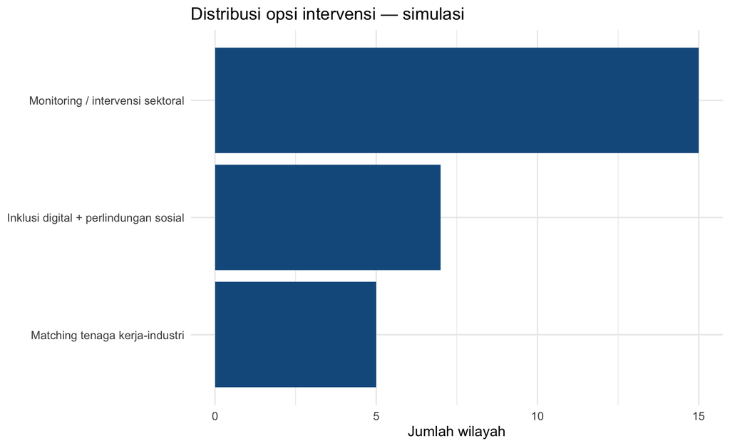

```r
latest |>
  dplyr::count(prioritas) |>
  ggplot2::ggplot(ggplot2::aes(reorder(prioritas, n), n)) +
  ggplot2::geom_col(fill = "#145B8C") +
  ggplot2::coord_flip() +
  ggplot2::labs(title = "Distribusi opsi intervensi — simulasi", x = NULL, y = "Jumlah wilayah")
```

## 15.7 Contoh dengan Data Nyata

Untuk dashboard Jawa Barat, sumber data dapat berasal dari Open Data Jabar/BPS; dashboard harus menampilkan tahun data, sumber, status angka, dan definisi indikator pada tooltip/metadata. Jangan mencampur indikator 2025 dan 2022 dalam satu “snapshot 2025” tanpa label.

**Kartu dataset real.**

- **Nama:** Open Data Jawa Barat—contoh TPT, kemiskinan, populasi, dan UMKM untuk *policy dashboard*.
- **Sumber dan URL:** portal Open Data Jawa Barat https://opendata.jabarprov.go.id/; halaman dataset spesifik dicatat pada `data/katalog_data_real.csv`.
- **Tahun:** berbeda antarindikator (mis. TPT 2007–2024; kemiskinan 2002–2025; populasi 2010–2025; UMKM 2016–2023).
- **Unit observasi:** kabupaten/kota–tahun.
- **Variabel/definisi:** kode/nama wilayah, nilai indikator, satuan, tahun; setiap tooltip/dashboard wajib menampilkan definisi dan tahun sumber.
- **Alasan digunakan:** data terbaru relatif mudah diakses dan relevan untuk stakeholder regional Jawa Barat.
- **Keterbatasan:** vintage tidak seragam dan status angka dapat berbeda (observasi/proyeksi); dashboard tidak boleh menyamarkan perbedaan tersebut sebagai satu snapshot yang seragam. (Pemerintah Provinsi Jawa Barat 2026b)

## 15.8 Analisis Menggunakan R

```r
map_policy <- latest
leaflet::leaflet(map_policy) |>
  leaflet::addProviderTiles("CartoDB.Positron") |>
  leaflet::addCircleMarkers(~longitude, ~latitude, radius = 6,
    popup = ~paste0("<b>", wilayah, "</b><br>", prioritas))
```

[interactive chart not shown]

### 15.8.1 Protokol penggunaan Generative AI

Gunakan tabel log berikut untuk project:

| Elemen | Contoh isi |
| --- | --- |
| Tool/model | Nama layanan/model yang digunakan |
| Tanggal | YYYY-MM-DD |
| Tujuan | Debugging `pivot_longer()` / ide visualisasi / dokumentasi |
| Ringkasan prompt | Bukan data rahasia; cukup ringkas tujuan |
| Output yang dipakai | Fungsi/kode/paragraf apa yang diadaptasi |
| Verifikasi | Dibandingkan dokumentasi resmi, unit test, cek hasil manual |
| Modifikasi manusia | Perubahan yang dilakukan mahasiswa |

**Tidak diperbolehkan:** membuat sumber/referensi fiktif, mengunggah data individual rahasia tanpa izin, menyalin interpretasi AI tanpa pemeriksaan, atau menyembunyikan penggunaan AI ketika berkontribusi substantif pada produk akhir.

## 15.9 Interpretasi dalam Konteks Regional

Policy recommendation perlu memiliki tingkat kepastian yang sebanding dengan bukti. Gunakan bahasa “data menunjukkan asosiasi/pola”, “model memprediksi”, atau “hasil mendukung prioritas eksplorasi”, bukan klaim sebab-akibat yang tidak didukung desain.

## 15.10 Latihan

1. Apa beda evidence-based dan model-based policy?
2. Mengapa AI output harus diverifikasi ke dokumentasi resmi?
3. Apa yang harus dilaporkan dalam AI-use declaration?
4. **Analisis:** ubah tiga temuan statistik menjadi rekomendasi SMART yang masih menyebut keterbatasan.
5. **Analisis:** buat prototype dashboard dengan 3 KPI dan 2 filter.
6. **Mini-case:** AI menyarankan bahwa korelasi -0,7 membuktikan dampak program. Tulis koreksi metodologis dan cara mengecek klaim tersebut.

### 15.10.1 Tugas Terstruktur Pertemuan 15

Buat **policy translation memo** maksimum 2 halaman: tiga temuan, dua opsi kebijakan, satu rekomendasi, stakeholder, implementation risk, data limitation, dan indikator monitoring. Lampirkan screenshot/dashboard beta. Isi AI-use log bila AI digunakan.

### 15.10.2 Kuis Formatif Pertemuan 15

1. Mengapa ranking model tidak otomatis menjadi ranking kebijakan?
2. Apa fungsi constraint anggaran dalam prioritization?
3. Apa empat lapis validasi output AI?
4. Informasi apa yang wajib muncul pada KPI dashboard?
5. Sebutkan data yang tidak layak ditempelkan ke layanan AI publik.

## 15.11 Hubungan dengan Capstone Project

Minggu 15 adalah *policy and communication gate*: kelompok menyerahkan dashboard beta, policy memo 2 halaman, AI-use log, dan mendapatkan peer review.

## 15.12 Kesimpulan

Nilai sains data muncul ketika bukti diterjemahkan menjadi keputusan secara transparan. AI dapat mempercepat kerja, tetapi tanggung jawab ilmiah tetap berada pada analis manusia.

## 15.13 Pendalaman Magister — Policy translation dan responsible AI

### 15.13.1 Audit metodologis

1. Dashboard tanpa definisi kpi.
2. Data historical ditampilkan sebagai current.
3. Ai source tidak diverifikasi.
4. Kode ai berjalan tapi salah konsep.
5. Recommendation melampaui evidence.
6. Data sensitif dikirim ke layanan publik.

### 15.13.2 Pertanyaan viva / diskusi kelas

1. Apa perbedaan model score dan policy score?
2. Bagaimana budget constraint mengubah ranking?
3. Apa empat lapis AI verification?
4. Apa yang harus ada pada AI-use declaration?
5. Bagaimana data freshness ditampilkan?
6. Apa evidence chain untuk satu recommendation?

# 16 Final Project Presentation, UAS, dan Reproducibility Audit

## 16.1 Pendahuluan

Pertemuan akhir menguji dua hal berbeda: **produk tim** melalui presentasi capstone dan **penguasaan individu** melalui UAS/defense. Pemisahan ini mencegah keberhasilan kelompok menutupi ketidaksiapan individu.

## 16.2 Tujuan Pembelajaran

Mahasiswa mampu mempertahankan keputusan analitik, menjawab kritik, menunjukkan reproducibility, membedakan evidence dari asumsi, dan menyusun rekomendasi regional yang proporsional.

## 16.3 Definisi dan Konsep

Reproducibility audit memeriksa apakah data, kode, seed, dependency, dan output dapat ditelusuri. Replicability lebih luas dan berkaitan dengan apakah temuan serupa diperoleh dengan data/prosedur baru. Untuk mata kuliah ini, fokus minimum adalah reproducibility.

## 16.4 Formulasi Matematis

Tidak ada formula baru. Mahasiswa harus mampu menjelaskan kembali metric/model yang digunakan pada project, termasuk unit outcome dan arti koefisien/probabilitas/cluster/metric.

### 16.4.2 Reproducibility audit score

Gunakan checklist dengan komponen $c_j\in\{0,1\}$ dan bobot $w_j$:
$$R=100\sum_{j=1}^{m}w_jc_j,\qquad \sum_jw_j=1.$$
Komponen minimum: data provenance, raw/processed separation, executable script, fixed seed, environment information, model object/parameter, generated tables/figures, AI declaration, dan README.

### 16.4.3 UAS analytical synthesis

Mahasiswa menerima satu mini-case atau cuplikan hasil analisis yang belum sempurna dan harus:

1. mengidentifikasi problem framing;
2. memilih/menilai metode;
3. membaca output/metric;
4. menemukan potensi leakage/bias;
5. menginterpretasikan secara regional;
6. mengusulkan satu perbaikan model dan satu perbaikan kebijakan.

Kisi-kisi UAS:

| Area | Proporsi skor UAS | Fokus |
| --- | --- | --- |
| Integrasi workflow | 15% | problem→data→model→decision |
| ML/classification | 20% | tree/ensemble/logit/threshold/metrics |
| Unsupervised & spatial | 20% | cluster/PCA/Moran/peta |
| Validation & uncertainty | 20% | resampling, calibration, sensitivity, fairness |
| Policy & AI governance | 15% | evidence-based recommendation, AI declaration |
| Oral defense | 10% | menjelaskan keputusan analitik secara individual |

### 16.4.4 Pertanyaan oral defense contoh

- “Mengapa Anda menggunakan kabupaten-tahun sebagai unit observasi?”
- “Apa yang terjadi pada hasil jika data tahun pandemi dikeluarkan?”
- “Mengapa threshold klasifikasi Anda 0,35 dan bukan 0,5?”
- “Apa baseline yang Anda kalahkan dan seberapa besar perbaikannya?”
- “Apakah feature importance dapat ditafsirkan sebagai pengaruh kausal? Mengapa?”
- “Bagaimana hasil berubah jika matriks tetangga memakai k-nearest neighbors?”
- “Bagian mana dari analisis yang dibantu Generative AI dan bagaimana diverifikasi?”

### 16.4.5 Standar final project package

Folder minimum:

```
capstone/
  README.md
  data_raw/            # bila lisensi mengizinkan
  data_processed/
  R/
    01_import.R
    02_clean.R
    03_eda.R
    04_model.R
    05_validate.R
    06_visualize.R
  report/
    final_report.Rmd
  dashboard/
  output/
  metadata/
    data_dictionary.csv
    provenance.csv
    ai_use_log.csv
  sessionInfo.txt
```

Final package dianggap berhasil jika dosen dapat mengikuti README dan meregenerasi tabel/grafik utama tanpa menebak langkah tersembunyi.

## 16.5 Intuisi Metode

Jika sebuah angka pada slide tidak dapat ditelusuri ke kode atau tabel sumber, angka tersebut belum siap menjadi bukti kebijakan. *Audit trail* adalah perlindungan terhadap kesalahan analitik dan ketergantungan berlebihan pada AI.

### 16.5.1 Contoh perhitungan nilai akhir

Mahasiswa memperoleh Project=84, Partisipasi=90, Kuis=80, Tugas=88, UTS=76, UAS=82. Nilai numerik:
$$NA=0.30(84)+0.10(90)+0.10(80)+0.10(88)+0.20(76)+0.20(82).$$
$$NA=25.2+9+8+8.8+15.2+16.4=82.6.$$
Konversi ke huruf mengikuti ketentuan akademik program/universitas yang berlaku; e-book tidak menetapkan boundary huruf bila belum diberikan secara resmi.

### 16.5.2 Oral defense diagnostic

Oral defense bertujuan membedakan **team product** dan **individual understanding**. Dosen dapat memilih satu grafik, satu formula, satu code chunk, dan satu recommendation secara acak. Mahasiswa harus menjelaskan: - apa input dan output; - mengapa metode dipilih; - apa asumsi; - apa alternative; - apa keterbatasan; - bagaimana hasil memengaruhi keputusan.

### 16.5.3 Reproducibility audit practical test

Dosen/peer reviewer menjalankan project dari clean session. Failure modes umum:

1. absolute path lokal;
2. package tidak disebut;
3. data processed diedit manual;
4. seed tidak ditetapkan;
5. object dibuat interaktif tetapi tidak ada pada script;
6. dashboard membaca file di folder pribadi;
7. source URL hilang;
8. AI-generated function tidak terdokumentasi.

### 16.5.4 Final policy-defense question matrix

| Pertanyaan | Bukti yang diharapkan |
| --- | --- |
| “Apa masalahnya?” | decision question dan stakeholder |
| “Mengapa data ini?” | metadata, representativeness, period |
| “Mengapa model ini?” | baseline comparison + validation |
| “Seberapa pasti?” | CV/bootstrap/sensitivity/calibration |
| “Apakah adil?” | subgroup analysis bila relevan |
| “Apakah spasial?” | map + W sensitivity jika dipakai |
| “Apa tindakan?” | recommendation traceable to findings |
| “Apa peran AI?” | AI-use log + verification |

### 16.5.5 Final report architecture

1. Executive summary (1 halaman)
2. Problem and decision context
3. Data and provenance
4. Methods dengan formula/asumsi
5. EDA and regional evidence
6. Models and validation
7. Robustness/uncertainty/fairness
8. Spatial/segmentation evidence bila relevan
9. Policy options and recommendation
10. Limitations
11. Reproducibility and AI declaration
12. References + appendices

### 16.5.6 Kriteria “master-level”

Pekerjaan magister tidak ditentukan oleh jumlah algoritma. Standar yang diharapkan adalah **argumentasi**: mahasiswa mampu menjelaskan mengapa satu pilihan analitik lebih defensible daripada alternatif, mengukur uncertainty, mengenali asumsi yang rapuh, serta menahan diri dari klaim yang tidak didukung. Project dengan model sederhana tetapi argumentasi, validasi, dan policy translation kuat dapat lebih unggul daripada model kompleks yang tidak dipahami.

## 16.6 Contoh dengan Data Simulasi

```r
# Contoh artefak audit sederhana.
files_needed <- c(
  "Sains_Data_Inovasi_Regional.Rmd",
  "references.bib",
  "data/simulasi_panel_regional.csv",
  "R/00_setup.R"
)
tibble(file = files_needed, tersedia = file.exists(files_needed)) |>
  knitr::kable(caption = "Contoh reproducibility checklist")
```

Table 16.1: Contoh reproducibility checklist

| file | tersedia |
| --- | --- |
| Sains_Data_Inovasi_Regional.Rmd | TRUE |
| references.bib | TRUE |
| data/simulasi_panel_regional.csv | TRUE |
| R/00_setup.R | TRUE |

### 16.6.1 Visualisasi Output: Reproducibility Status

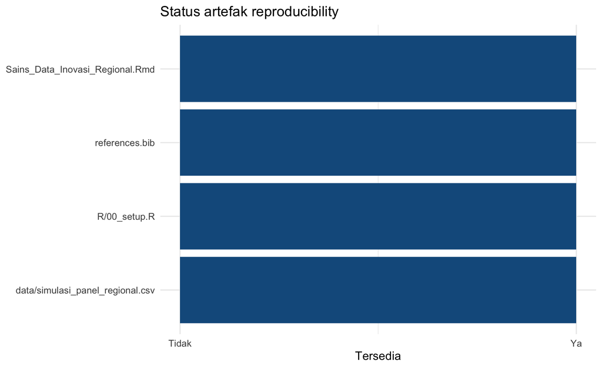

```r
audit_plot <- tibble::tibble(file = files_needed, tersedia = file.exists(files_needed))
ggplot2::ggplot(audit_plot, ggplot2::aes(reorder(file, tersedia), as.integer(tersedia), fill = tersedia)) +
  ggplot2::geom_col(show.legend = FALSE) +
  ggplot2::coord_flip() +
  ggplot2::scale_y_continuous(breaks = c(0,1), labels = c("Tidak", "Ya")) +
  ggplot2::scale_fill_manual(values = c("TRUE" = "#145B8C", "FALSE" = "#C99A17")) +
  ggplot2::labs(title = "Status artefak reproducibility", x = NULL, y = "Tersedia")
```

## 16.7 Contoh dengan Data Nyata

Untuk data open data, tim menyimpan **URL sumber dan metadata**, bukan mengklaim kepemilikan data. Bila lisensi membatasi redistribusi, repository menyimpan script download dan checksum/versi, bukan file mentah.

**Kartu dataset real untuk final project.**

- **Nama:** ditentukan tim dari BPS/Open Data Jawa Barat/data.go.id/World Bank/WHO/UNData; contoh minimum yang dapat direplikasi adalah TPT kabupaten/kota Jawa Barat.
- **Sumber dan URL contoh:** Open Data Jawa Barat/BPS, https://opendata.jabarprov.go.id/id/dataset/tingkat-pengangguran-terbuka-berdasarkan-kabupatenkota-di-jawa-barat.
- **Tahun contoh:** 2007–2024.
- **Unit observasi contoh:** kabupaten/kota–tahun.
- **Variabel/definisi contoh:** identitas wilayah, TPT (%), satuan, tahun. Untuk dataset tim, semua variabel harus ditulis dalam data dictionary beserta unit/denominator.
- **Alasan digunakan:** audit final menilai kemampuan mendokumentasikan dan mereplikasi data nyata, bukan sekadar menampilkan output yang sudah jadi.
- **Keterbatasan:** keterbatasan mengikuti dataset pilihan; tim wajib menyertakan lisensi, tanggal akses, checksum/versi bila relevan, dan instruksi download bila raw data tidak boleh didistribusikan. (Pemerintah Provinsi Jawa Barat 2026b)

## 16.8 Analisis Menggunakan R

[session information not shown]

Checklist akhir repository:

1. `README` menjelaskan pertanyaan, data, cara menjalankan project.
2. `data/raw` tidak berisi data sensitif.
3. script cleaning terpisah dari analisis atau jelas urutannya.
4. seed dicatat pada proses acak.
5. output utama dapat dibuat ulang.
6. model metric dihitung pada holdout/resampling yang benar.
7. AI-use declaration tersedia.
8. keterbatasan dan risiko misuse ditulis.

## 16.9 Interpretasi dalam Konteks Regional

Presentasi final harus berakhir dengan **opsi tindakan dan batas bukti**, bukan dengan “akurasi model 87%”. Contoh penutup yang lebih substantif: “Model membantu menyaring 20% wilayah dengan risiko tertinggi, tetapi error lebih besar pada wilayah berdata jarang; karena itu rekomendasi kami adalah menggunakan model sebagai tahap screening yang diikuti verifikasi lapangan, bukan keputusan otomatis.”

## 16.10 Latihan

1. Bedakan reproducibility dan replicability.
2. Apa yang harus dilakukan jika hasil slide tidak cocok dengan output script terbaru?
3. Mengapa repository perlu mencatat versi package?
4. **Analisis:** minta rekan menjalankan ulang satu analisis tanpa instruksi verbal; catat titik yang gagal.
5. **Analisis:** buat model card final satu halaman.
6. **Mini-case:** setelah presentasi, stakeholder meminta ranking individu warga. Jelaskan apakah model level kabupaten dapat digunakan dan mengapa.

### 16.10.1 UAS — Individual Analytical Synthesis & Defense (20%)

UAS terdiri dari **analytical synthesis individual** dan **oral defense**. Mahasiswa tidak dinilai dari hafalan syntax R, tetapi dari kemampuan menjelaskan keputusan analitik, membaca output, menemukan risiko validitas, dan menghubungkan hasil dengan keputusan regional.

### 16.10.2 Checklist Final Project Presentation

- masalah dan stakeholder jelas dalam ≤90 detik;
- sumber data dan periode disebutkan;
- satu diagram workflow;
- EDA menunjukkan disparitas yang relevan;
- baseline dan model utama dibandingkan;
- metrik dipilih sesuai target;
- uncertainty/sensitivity ditampilkan;
- rekomendasi tidak melampaui bukti;
- dashboard hanya menampilkan indikator yang terdefinisi;
- repository/package dapat direproduksi;
- penggunaan AI dideklarasikan.

## 16.11 Hubungan dengan Capstone Project

Milestone akhir: repository reproducible, dashboard/visual, policy memo, presentasi, dan defense. UAS individual menguji kemampuan menjelaskan metode serta mengkritik keterbatasan proyek.

## 16.12 Kesimpulan

Capstone yang baik dapat diaudit, direproduksi, dan dipertahankan secara substantif. Tujuan akhir bukan memamerkan algoritma, tetapi meningkatkan kualitas keputusan regional dengan bukti yang transparan.

# Pendalaman Akhir: Synthesis, Reproducibility, dan Defense

## Audit metodologis

1. Team product menutupi pemahaman individu.
2. File hanya berjalan di laptop pembuat.
3. Ai use tidak dideklarasikan.
4. Hasil utama tidak dapat diregenerasi.
5. Limitation disembunyikan.
6. Presentasi terlalu teknis tanpa decision implication.

## Pertanyaan Viva / Diskusi Kelas

1. Bagaimana membuktikan project reproducible?
2. Apa keputusan analitik paling sulit?
3. Bagaimana hasil berubah pada skenario alternatif?
4. Apa satu klaim yang harus diturunkan karena bukti terbatas?
5. Bagaimana kontribusi AI diverifikasi?
6. Apa tindakan stakeholder besok pagi setelah membaca laporan?

# Daftar Rumus Inti

Bagian ini berfungsi sebagai indeks cepat. Penjelasan, asumsi, dan contoh terdapat pada bab terkait.

| Topik | Rumus inti |
| --- | --- |
| Weighted index | $S_i=\sum_jw_jz_{ij}$ |
| Rate | $r=(a/b)k$ |
| Growth | $g_t=(x_t-x_{t-1})/x_{t-1}$ |
| Z-score | $z=(x-\bar x)/s$ |
| Mean/variance | $\bar x=n^{-1}\sum x_i$, $s^2=(n-1)^{-1}\sum(x_i-\bar x)^2$ |
| Correlation | $r=Cov(X,Y)/(s_Xs_Y)$ |
| Gini | $G=2\sum i x_{(i)}/(n\sum x_i)-(n+1)/n$ |
| OLS | $\hat\beta=(X'X)^{-1}X'y$ |
| $R^2$ | $1-SSE/SST$ |
| VIF | $1/(1-R_j^2)$ |
| RMSE | $\sqrt{n^{-1}\sum(y-\hat y)^2}$ |
| MAE | $n^{-1}\sum\|y-\hat y\|$ |
| Ridge | $SSE+\lambda\sum\beta_j^2$ |
| Lasso | $SSE+\lambda\sum\|\beta_j\|$ |
| Gini impurity | $1-\sum_kp_k^2$ |
| RF regression | $B^{-1}\sum_b\hat f_b(x)$ |
| Logistic | $p=e^\eta/(1+e^\eta)$ |
| Sensitivity | $TP/(TP+FN)$ |
| Precision | $TP/(TP+FP)$ |
| F1 | $2PR/(P+R)$ |
| K-means | $\sum_k\sum_{i\in C_k}\\|x_i-\mu_k\\|^2$ |
| Silhouette | $(b-a)/\max(a,b)$ |
| PCA eigen | $Sv_k=\lambda_kv_k$ |
| PVE | $\lambda_k/\sum_j\lambda_j$ |
| Moran’s I | $\frac{n}{S_0}\frac{\sum_{ij}w_{ij}z_iz_j}{\sum_i z_i^2}$ |
| Bootstrap SE | $\sqrt{(B-1)^{-1}\sum_b(\theta_b^*-\bar\theta^*)^2}$ |
| DID | $(\bar Y_{T,post}-\bar Y_{T,pre})-(\bar Y_{C,post}-\bar Y_{C,pre})$ |

# Glosarium Sains Data Regional

| Istilah | Definisi operasional dalam mata kuliah |
| --- | --- |
| **Analytical question** | pertanyaan yang dapat dijawab dengan data/metode dan diturunkan dari masalah keputusan |
| **Outcome** | variabel target yang dijelaskan, diprediksi, atau dievaluasi |
| **Feature/predictor** | informasi yang digunakan untuk menjelaskan/memprediksi outcome |
| **Unit observasi** | entitas satu baris data, misalnya kabupaten–tahun |
| **Unit analisis** | unit yang menjadi dasar inferensi/interpretasi; sering sama tetapi tidak selalu dengan unit observasi |
| **Denominator** | populasi dasar suatu rate/proportion |
| **Provenance** | jejak asal data, versi, transformasi, lisensi, dan tanggal akses |
| **Metadata** | informasi tentang definisi, satuan, periode, metode produksi, dan struktur data |
| **Tidy data** | struktur satu variabel per kolom, satu observasi per baris, satu jenis unit per tabel |
| **Missingness** | keadaan nilai tidak teramati; mekanismenya dapat memengaruhi bias |
| **Outlier** | observasi ekstrem; dapat berupa error atau fenomena substantif valid |
| **Feature engineering** | konstruksi fitur baru dari data mentah untuk merepresentasikan konsep yang lebih relevan |
| **Leakage** | informasi yang tidak seharusnya tersedia saat prediksi masuk ke training/preprocessing |
| **EDA** | exploratory data analysis: iterasi pertanyaan–visualisasi–pola–pertanyaan baru |
| **Association** | hubungan statistik, tidak otomatis kausal |
| **Prediction** | estimasi outcome pada observasi/waktu baru |
| **Causal effect** | perubahan outcome akibat intervensi/perlakuan di bawah definisi estimand dan asumsi identifikasi |
| **Baseline model** | model/rule sederhana sebagai pembanding wajib |
| **Loss function** | fungsi yang mengukur biaya kesalahan prediksi |
| **Empirical risk** | rata-rata loss pada sample training |
| **Generalization** | kemampuan perform pada data baru dari target deployment |
| **Cross-validation** | resampling untuk estimasi perform/tuning menggunakan training data |
| **RMSE** | akar mean squared error; menekankan error besar |
| **MAE** | mean absolute error; error absolut rata-rata |
| **Calibration** | kesesuaian predicted probability dengan observed frequency |
| **Discrimination** | kemampuan model membedakan/ranking kelas positif vs negatif |
| **Threshold** | batas probabilitas/score untuk mengubah prediksi menjadi tindakan/kelas |
| **Random forest** | ensemble randomized decision trees dengan agregasi prediksi |
| **Boosting** | ensemble sequential yang menambah weak learners untuk mengurangi loss |
| **Regularization** | penalti kompleksitas untuk mengontrol variance/overfitting |
| **Clustering** | pengelompokan unsupervised berdasarkan similarity yang didefinisikan |
| **Centroid** | pusat rata-rata cluster dalam K-means |
| **Silhouette** | ukuran compactness dan separation per observasi |
| **PCA** | rotasi linear yang mencari arah variance maksimum |
| **Loading** | coefficient/eigenvector yang membentuk principal component |
| **Score PCA** | koordinat observasi pada principal component |
| **PVE** | proportion of variance explained oleh komponen |
| **CRS** | coordinate reference system untuk menginterpretasi koordinat spasial |
| **Spatial weights $W$** | definisi matematis siapa bertetangga/berinteraksi dengan siapa |
| **Spatial lag** | weighted combination nilai pada tetangga |
| **Moran’s I** | ukuran global spatial autocorrelation |
| **LISA** | local indicators of spatial association |
| **MAUP** | perubahan hasil akibat skala/zoning unit areal |
| **Ecological fallacy** | kesalahan menerapkan hubungan agregat kepada individu |
| **Bootstrap** | resampling dengan replacement untuk mengestimasi sampling variability |
| **Robustness** | kestabilan kesimpulan terhadap reasonable analytic alternatives |
| **Sensitivity analysis** | evaluasi bagaimana hasil berubah saat asumsi/parameter diubah |
| **Fairness** | evaluasi distribusi perform/keputusan di kelompok relevan; definisinya kontekstual |
| **DID** | difference-in-differences untuk evaluasi perubahan treated vs control dengan asumsi tertentu |
| **Policy brief** | dokumen ringkas yang menghubungkan bukti, opsi, rekomendasi, dan caveat |
| **Dashboard** | antarmuka monitoring/exploration; bukan pengganti analisis metodologis |
| **Reproducibility** | kemampuan pihak lain meregenerasi hasil dari data, kode, parameter, dan environment |
| **AI-use declaration** | catatan transparan tentang tujuan, bagian yang dibantu AI, dan metode verifikasi |
| **Model card** | dokumentasi intended use, data, metrics, limitations, dan risiko model |
| **Datasheet** | dokumentasi asal, komposisi, collection, preprocessing, penggunaan, limitations dataset |

# Derivasi Ringkas Rumus-Rumus Kunci

## 16.13 Derivasi OLS Normal Equations

Mulai dari objective
$$S(\beta)=(y-X\beta)'(y-X\beta).$$
Ekspansi:
$$S=y'y-2\beta'X'y+\beta'X'X\beta.$$
Turunkan terhadap $\beta$:
$$\frac{\partial S}{\partial\beta}=-2X'y+2X'X\beta.$$
Set sama dengan nol:
$$X'X\hat\beta=X'y.$$
Jika $X'X$ invertibel:
$$\boxed{\hat\beta=(X'X)^{-1}X'y}.$$
Ini menunjukkan OLS berasal langsung dari minimisasi SSE, bukan formula yang muncul tanpa alasan.

## 16.14 Mengapa mean meminimalkan squared error

Untuk konstanta $c$, minimalkan
$$Q(c)=\sum_i(y_i-c)^2.$$
Turunan:
$$Q'(c)=-2\sum_i(y_i-c)=-2\left(\sum_i y_i-nc\right).$$
Set nol memberi $c=\bar y$. Inilah alasan leaf prediction regression tree adalah mean pada node bila loss squared error.

## 16.15 Mengapa median meminimalkan absolute error

Untuk
$$Q(c)=\sum_i|y_i-c|,$$
fungsi tidak differentiable di data points, tetapi subgradient berubah tanda ketika jumlah observasi di bawah dan di atas $c$ seimbang. Solusi berada pada median. Ini menjelaskan hubungan natural MAE dengan median-type prediction.

## 16.16 Logistic inverse link

Dari
$$\log\frac{p}{1-p}=\eta,$$
exponentiate:
$$\frac{p}{1-p}=e^\eta.$$
Maka
$$p=e^\eta(1-p)=e^\eta-e^\eta p,$$
$$p(1+e^\eta)=e^\eta,$$
sehingga
$$\boxed{p=\frac{e^\eta}{1+e^\eta}=\frac{1}{1+e^{-\eta}}}.$$

## 16.17 PCA sebagai constrained maximization

Variance projection $X_cv$ adalah
$$Var(X_cv)=v'Sv.$$
Cari $v$ dengan $v'v=1$. Lagrangian:
$$\mathcal L(v,\lambda)=v'Sv-\lambda(v'v-1).$$
Turunan terhadap $v$:
$$2Sv-2\lambda v=0\Rightarrow Sv=\lambda v.$$
Jadi arah principal component adalah eigenvector covariance/correlation matrix.

## 16.18 Bias–variance decomposition ringkas

Misalkan $Y=f(x)+\varepsilon$, $E(\varepsilon)=0$, $Var(\varepsilon)=\sigma^2$. Untuk estimator $\hat f$:
$$E[(Y-\hat f)^2]=E[(f+\varepsilon-\hat f)^2].$$
Cross-term dengan $\varepsilon$ hilang karena mean nol dan independensi yang diasumsikan. Tambah-kurang $E\hat f$ menghasilkan
$$\sigma^2+[E\hat f-f]^2+E[(\hat f-E\hat f)^2].$$
Tiga komponen adalah irreducible noise, squared bias, dan variance.

## 16.19 K-means centroid update

Untuk satu cluster $C$, minimalkan
$$Q(\mu)=\sum_{i\in C}\|x_i-\mu\|^2.$$
Turunan vector:
$$\frac{\partial Q}{\partial\mu}=-2\sum_{i\in C}(x_i-\mu)=0,$$
sehingga
$$\boxed{\mu=|C|^{-1}\sum_{i\in C}x_i}.$$
Karena itu update centroid adalah mean anggota cluster.

## 16.20 Standard error mean

Jika $X_i$ independen dengan variance $\sigma^2$:
$$Var(\bar X)=Var\left(n^{-1}\sum_iX_i\right)=n^{-2}\sum_iVar(X_i)=\frac{\sigma^2}{n}.$$
Maka $SE(\bar X)=\sigma/\sqrt n$, diestimasi dengan $s/\sqrt n$.

## 16.21 Hubungan odds dan probability

Odds $o=p/(1-p)$. Sebaliknya
$$p=\frac{o}{1+o}.$$
Jika odds dikalikan OR, probability baru adalah
$$p' = \frac{OR\cdot p/(1-p)}{1+OR\cdot p/(1-p)}.$$
Rumus ini menunjukkan perubahan probability bergantung pada baseline $p$.

## 16.22 Moran’s I sebagai cross-product tetangga

Pembilang
$$\sum_i\sum_jw_{ij}z_iz_j$$
besar positif jika neighbors memiliki deviasi dengan tanda sama; negatif jika tanda berlawanan. Penyebut $\sum_i z_i^2$ menormalisasi overall variance dan $n/S_0$ menyesuaikan total bobot. Karena nilai ekspektasi null bergantung struktur W dan n, inference sebaiknya menggunakan teori/permutation yang tepat, bukan membandingkan sekadar dengan nol.

# Checklist Akhir untuk Mahasiswa

Sebelum menyerahkan tugas/project, pastikan:

- Pertanyaan kebijakan dan analytical question tidak rancu.
- Unit observasi dan outcome tertulis.
- Semua sumber data memiliki URL dan access date.
- Definisi denominator dan satuan diverifikasi.
- Raw data tidak ditimpa hasil cleaning.
- Duplicate, missing, outlier, join mismatch diaudit.
- Feature tidak menggunakan informasi masa depan.
- Baseline model tersedia.
- Split/resampling sesuai deployment.
- Test set tidak digunakan untuk tuning.
- Metrik diterjemahkan ke unit substantif.
- Model complexity memiliki alasan.
- Uncertainty/sensitivity dibahas.
- Spatial W/CRS dijelaskan bila dipakai.
- Recommendation tidak melampaui evidence.
- Dashboard memiliki source, period, definition.
- Semua kode dapat dijalankan dari clean session.
- `set.seed()` digunakan untuk operasi acak.
- AI-use declaration lengkap bila AI digunakan.
- Sitasi akademik dan sumber data diperiksa.

# Daftar Pustaka dan Sumber Data

Daftar pustaka berikut dihasilkan dari `references.bib`. URL sumber data dipertahankan agar mahasiswa dapat memeriksa metadata, tahun cakupan, versi, dan tanggal akses. Untuk dataset yang terus diperbarui, status data harus diverifikasi kembali pada saat project dikerjakan.

Anselin, Luc. 1995. “Local Indicators of Spatial Association—LISA.” *Geographical Analysis* 27 (2): 93–115. https://doi.org/10.1111/j.1538-4632.1995.tb00338.x.

Autio, Chloe, Reva Schwartz, Jesse Dunietz, Shomik Jain, Martin Stanley, Elham Tabassi, Patrick Hall, dan Kamie Roberts. 2024. “Artificial Intelligence Risk Management Framework: Generative Artificial Intelligence Profile.” NIST AI 600-1. National Institute of Standards; Technology. https://doi.org/10.6028/NIST.AI.600-1.

Badan Pusat Statistik. 2026. “Badan Pusat Statistik Republik Indonesia.” https://www.bps.go.id/.

Badan Pusat Statistik Provinsi Jawa Barat. 2025. *Kemiskinan Kabupaten/Kota di Provinsi Jawa Barat 2019–2024*. 32000.25002. Badan Pusat Statistik Provinsi Jawa Barat. https://jabar.bps.go.id/id/publication/2025/02/28/fe91e8d4537a17cb53916883/kemiskinan-kabupaten-kota-di-provinsi-jawa-barat-2019-2024.html.

Badan Pusat Statistik, dan Pemerintah Provinsi Jawa Barat. 2026a. “Jumlah Penduduk Miskin Berdasarkan Kabupaten/Kota di Jawa Barat.” https://opendata.jabarprov.go.id/id/dataset/jumlah-penduduk-miskin-berdasarkan-kabupatenkota-di-jawa-barat.

———. 2026b. “Laju Pertumbuhan Produk Domestik Regional Bruto Atas Dasar Harga Konstan Berdasarkan Kabupaten/Kota di Jawa Barat.” https://opendata.jabarprov.go.id/id/dataset/laju-pertumbuhan-produk-domestik-regional-bruto-atas-dasar-harga-konstan-berdasarkan-kabupatenkota-di-jawa-barat.

———. 2026c. “Persentase Penduduk Miskin Berdasarkan Kabupaten/Kota di Jawa Barat.” https://opendata.jabarprov.go.id/en/dataset/persentase-penduduk-miskin-berdasarkan-kabupatenkota-di-jawa-barat.

———. 2026d. “Tingkat Pengangguran Terbuka Berdasarkan Kabupaten/Kota di Jawa Barat.” https://opendata.jabarprov.go.id/id/dataset/tingkat-pengangguran-terbuka-berdasarkan-kabupatenkota-di-jawa-barat.

Bivand, Roger S., Edzer Pebesma, dan Virgilio Gómez-Rubio. 2013. *Applied Spatial Data Analysis with R*. 2 ed. New York: Springer. https://doi.org/10.1007/978-1-4614-7618-4.

Breiman, Leo. 2001. “Random Forests.” *Machine Learning* 45: 5–32. https://doi.org/10.1023/A:1010933404324.

Callaway, Brantly, dan Pedro H. C. Sant’Anna. 2021. “Difference-in-Differences with Multiple Time Periods.” *Journal of Econometrics* 225 (2): 200–230. https://doi.org/10.1016/j.jeconom.2020.12.001.

Chen, Tianqi, dan Carlos Guestrin. 2016. “XGBoost: A Scalable Tree Boosting System.” Dalam *Proceedings of the 22nd ACM SIGKDD International Conference on Knowledge Discovery and Data Mining*, 785–94. ACM. https://doi.org/10.1145/2939672.2939785.

Dinas Koperasi dan Usaha Kecil Provinsi Jawa Barat. 2026. “Proyeksi Jumlah Usaha Mikro Kecil Menengah (UMKM) Berdasarkan Kabupaten/Kota di Jawa Barat.” https://opendata.jabarprov.go.id/id/dataset/proyeksi-jumlah-usaha-mikro-kecil-menengah-umkm-berdasarkan-kabupatenkota-di-jawa-barat.

Fawcett, Tom. 2006. “An Introduction to ROC Analysis.” *Pattern Recognition Letters* 27 (8): 861–74. https://doi.org/10.1016/j.patrec.2005.10.010.

Friedman, Jerome H. 2001. “Greedy Function Approximation: A Gradient Boosting Machine.” *The Annals of Statistics* 29 (5): 1189–1232. https://doi.org/10.1214/aos/1013203451.

Gebru, Timnit, Jamie Morgenstern, Briana Vecchione, Jennifer Wortman Vaughan, Hanna Wallach, Hal Daumé III, dan Kate Crawford. 2021. “Datasheets for Datasets.” *Communications of the ACM* 64 (12): 86–92. https://doi.org/10.1145/3458723.

Hardt, Moritz, Eric Price, dan Nathan Srebro. 2016. “Equality of Opportunity in Supervised Learning.” *Advances in Neural Information Processing Systems* 29. https://proceedings.neurips.cc/paper/2016/hash/9d2682367c3935defcb1f9e247a97c0d-Abstract.html.

Harrell, Frank E. Jr. 2015. *Regression Modeling Strategies: With Applications to Linear Models, Logistic and Ordinal Regression, and Survival Analysis*. 2 ed. Cham: Springer. https://doi.org/10.1007/978-3-319-19425-7.

Hastie, Trevor, Robert Tibshirani, dan Jerome Friedman. 2009. *The Elements of Statistical Learning: Data Mining, Inference, and Prediction*. 2 ed. New York: Springer. https://doi.org/10.1007/978-0-387-84858-7.

Hernán, Miguel A., dan James M. Robins. 2020. *Causal Inference: What If*. Boca Raton, FL: Chapman; Hall/CRC. https://www.hsph.harvard.edu/miguel-hernan/causal-inference-book/.

Hoerl, Arthur E., dan Robert W. Kennard. 1970. “Ridge Regression: Biased Estimation for Nonorthogonal Problems.” *Technometrics* 12 (1): 55–67. https://doi.org/10.1080/00401706.1970.10488634.

James, Gareth, Daniela Witten, Trevor Hastie, dan Robert Tibshirani. 2021. *An Introduction to Statistical Learning: with Applications in R*. 2 ed. New York: Springer. https://doi.org/10.1007/978-1-0716-1418-1.

Jolliffe, Ian T., dan Jorge Cadima. 2016. “Principal Component Analysis: A Review and Recent Developments.” *Philosophical Transactions of the Royal Society A: Mathematical, Physical and Engineering Sciences* 374 (2065): 20150202. https://doi.org/10.1098/rsta.2015.0202.

Kaufman, Leonard, dan Peter J. Rousseeuw. 1990. *Finding Groups in Data: An Introduction to Cluster Analysis*. New York: Wiley. https://doi.org/10.1002/9780470316801.

Kementerian Kesehatan Republik Indonesia, dan Pemerintah Provinsi Jawa Barat. 2026. “Prevalensi Balita Stunting Berdasarkan Kabupaten/Kota di Jawa Barat.” https://opendata.jabarprov.go.id/id/dataset/prevalensi-balita-stunting-berdasarkan-kabupatenkota-di-jawa-barat.

Kuhn, Max, dan Julia Silge. 2022. *Tidy Modeling with R: A Framework for Modeling in the Tidyverse*. Sebastopol, CA: O’Reilly Media. https://www.tmwr.org/.

Little, Roderick J. A., dan Donald B. Rubin. 2019. *Statistical Analysis with Missing Data*. 3 ed. Hoboken, NJ: Wiley. https://doi.org/10.1002/9781119482260.

Lovelace, Robin, Jakub Nowosad, dan Jannes Muenchow. 2025. *Geocomputation with R*. 2 ed. Boca Raton, FL: Chapman; Hall/CRC. https://r.geocompx.org/.

Miao, Fengchun, dan Wayne Holmes. 2023. *Guidance for Generative AI in Education and Research*. Paris: UNESCO. https://unesdoc.unesco.org/ark:/48223/pf0000386693.

Mitchell, Margaret, Simone Wu, Andrew Zaldivar, Parker Barnes, Lucy Vasserman, Ben Hutchinson, Elena Spitzer, Inioluwa Deborah Raji, dan Timnit Gebru. 2019. “Model Cards for Model Reporting.” Dalam *Proceedings of the Conference on Fairness, Accountability, and Transparency*, 220–29. ACM. https://doi.org/10.1145/3287560.3287596.

Moran, P. A. P. 1950. “Notes on Continuous Stochastic Phenomena.” *Biometrika* 37 (1/2): 17–23. https://doi.org/10.2307/2332142.

OECD, dan Joint Research Centre, European Commission. 2008. *Handbook on Constructing Composite Indicators: Methodology and User Guide*. Paris: OECD Publishing. https://doi.org/10.1787/9789264043466-en.

Pebesma, Edzer. 2018. “Simple Features for R: Standardized Support for Spatial Vector Data.” *The R Journal* 10 (1): 439–46. https://doi.org/10.32614/RJ-2018-009.

Pebesma, Edzer, dan Roger Bivand. 2023. *Spatial Data Science: With Applications in R*. Boca Raton, FL: Chapman; Hall/CRC. https://r-spatial.org/book/.

Pemerintah Provinsi Jawa Barat. 2026a. “Luas Areal Tanam Padi Sawah Berdasarkan Kabupaten/Kota di Jawa Barat.” https://opendata.jabarprov.go.id/id/dataset/luas-areal-tanam-padi-sawah-berdasarkan-kabupatenkota-di-jawa-barat.

———. 2026b. “Open Data Jawa Barat.” https://opendata.jabarprov.go.id/.

Provost, Foster, dan Tom Fawcett. 2013. *Data Science for Business: What You Need to Know about Data Mining and Data-Analytic Thinking*. Sebastopol, CA: O’Reilly Media.

Rousseeuw, Peter J. 1987. “Silhouettes: A Graphical Aid to the Interpretation and Validation of Cluster Analysis.” *Journal of Computational and Applied Mathematics* 20: 53–65. https://doi.org/10.1016/0377-0427(87)90125-7.

Sekolah Pascasarjana Universitas Padjadjaran. 2026. “Profil Magister Inovasi Regional.” https://pasca.unpad.ac.id/profil-magister-inovasi-regional/.

Tabassi, Elham. 2023. “Artificial Intelligence Risk Management Framework (AI RMF 1.0).” NIST AI 100-1. National Institute of Standards; Technology. https://doi.org/10.6028/NIST.AI.100-1.

Tibshirani, Robert. 1996. “Regression Shrinkage and Selection via the Lasso.” *Journal of the Royal Statistical Society: Series B (Methodological)* 58 (1): 267–88. https://doi.org/10.1111/j.2517-6161.1996.tb02080.x.

Tufte, Edward R. 2001. *The Visual Display of Quantitative Information*. 2 ed. Cheshire, CT: Graphics Press.

Tukey, John W. 1977. *Exploratory Data Analysis*. Reading, MA: Addison-Wesley.

Wickham, Hadley. 2014. “Tidy Data.” *Journal of Statistical Software* 59 (10): 1–23. https://doi.org/10.18637/jss.v059.i10.

Wickham, Hadley, Mine Çetinkaya-Rundel, dan Garrett Grolemund. 2023. *R for Data Science: Import, Tidy, Transform, Visualize, and Model Data*. 2 ed. Sebastopol, CA: O’Reilly Media. https://r4ds.hadley.nz/.

Wilkinson, Leland. 2005. *The Grammar of Graphics*. 2 ed. New York: Springer. https://doi.org/10.1007/0-387-28695-0.

World Bank. 2026. “Indonesia Database for Policy and Economic Research (INDO-DAPOER).” https://datacatalog.worldbank.org/search/dataset/0041056/indonesia-database-for-policy-and-economic-research.